# Model building: Time-series decomposition for birthdays

Author

Aki Vehtari

Published

2020-12-28

Modified

2026-08-20

This notebook includes the code for Bayesian Workflow book Chapter 27 *Model building: Time-series decomposition for birthdays*.

# 1 Introduction

We analyse the relative number of births per day in USA 1969–1988 using Gaussian process time series model with several model components that can explain the long term, seasonal, weekly, day of year, and special floating day variation. We use Hilbert space Gaussian process approximation (Riutort-Mayol et al. 2023) to speed up the computation.

We also illustrate the use Pathfinder algorithm (Zhang et al. 2022) to quickly check that model code produces something reasonable and to initialize MCMC sampling.

Stan model codes are available in [the corresponding git repo](https://github.com/avehtari/Bayesian-Workflow/tree/master/birthdays).

*Load packages*

```r
library(rprojroot)
root <- has_file(".Bayesian-Workflow-root")$make_fix_file()
library(tidyverse)
library(tictoc)
mytoc <- \() {
  toc(func.toc = \(tic, toc, msg) {
    sprintf("%s took %s sec", msg, as.character(signif(toc - tic, 2)))
  })}
library(cmdstanr)
# CmdStanR output directory makes Quarto cache to work
dir.create(root("birthdays", "stan_output"), showWarnings = FALSE)
options(cmdstanr_output_dir = root("birthdays", "stan_output"))
library(posterior)
options(pillar.neg = FALSE,
        pillar.subtle = FALSE,
        pillar.sigfig = 2)
library(tinytable)
options(tinytable_format_num_fmt = "significant_cell",
        tinytable_format_digits = 2,
        tinytable_tt_digits = 2)
# requires loo 2.10.0 or later
library(loo)
library(bayesplot)
theme_set(bayesplot::theme_default(base_family = "sans"))
library(ggdist)
library(patchwork)
library(ggrepel)
library(RColorBrewer)
set1 <- brewer.pal(7, "Set1")
```

Use English for names of weekdays and months

```r
Sys.setlocale("LC_TIME", "en_GB.utf8")
```

```
[1] "en_GB.utf8"
```

Source common helpers for figures

```r
source(root("birthdays", "plot_helpers.R"))
```

# 2 Data

Load birthdays per day in USA 1969-1988:

```r
birthdays <- read_csv(root("birthdays/data", "births_usa_1969.csv"))
```

Add date type column for plotting

```r
birthdays <- birthdays |>
  mutate(date = as.Date("1968-12-31") + id,
         births_relative100 = births / mean(births) * 100)
```

## 2.1 Plot all births

We can see slow variation in trend, yearly pattern, and especially in the later years spread to lower and higher values.

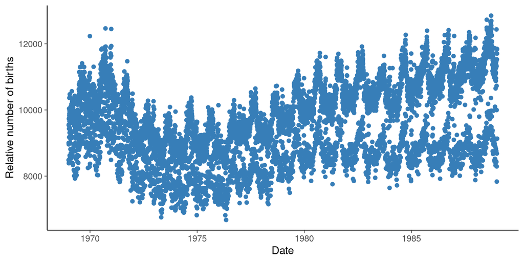

Figure 1

```r
birthdays |>
  ggplot(aes(x = date, y = births)) +
  geom_point(color = col_data) +
  labs(x = "Date", y = "Relative number of births")
```

## 2.2 Plot all births as relative to mean

To make the interpretation we switch to examine the relative change, with the mean level denoted with 100.

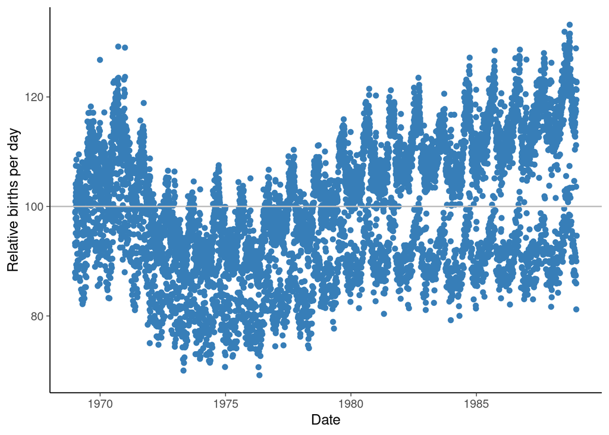

Figure 2

```r
birthdays |>
  ggplot(aes(x = date, y = births_relative100)) +
  geom_point(color = col_data) +
  layers_hline100 +
  labs(x = "Date", y = "Relative births per day")
```

## 2.3 Plot mean per day of year

We can see the generic pattern in yearly seasonal trend simply by averaging over each day of year (day_of_year has numbers from 1 to 366 every year with leap day being 60 and 1st March 61 also on non-leap-years).

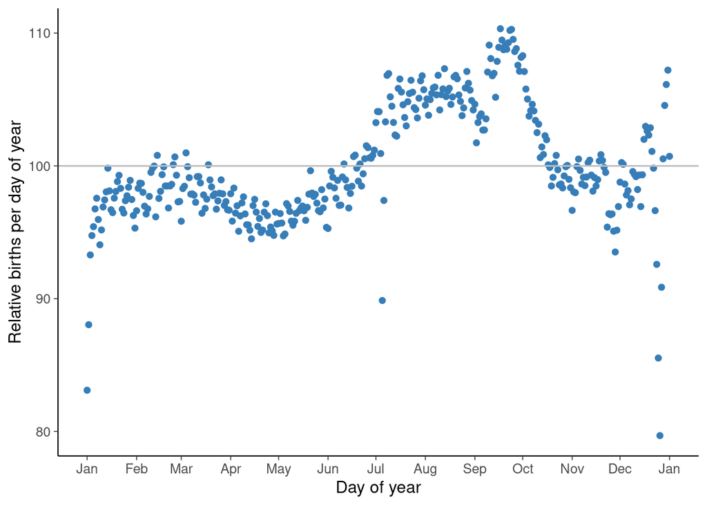

Figure 3

```r
birthdays |>
  group_by(day_of_year2) |>
  summarise(meanbirths = mean(births_relative100)) |>
  ggplot(aes(x = as.Date("1986-12-31") + day_of_year2, y = meanbirths)) +
  geom_point(color = col_data) +
  layers_hline100 +
  layers_scale_doy +
  labs(x = "Day of year", y = "Relative births per day of year")
```

## 2.4 Plot mean per day of week

We can see the generic pattern in weekly trend simply by averaging over each day of week.

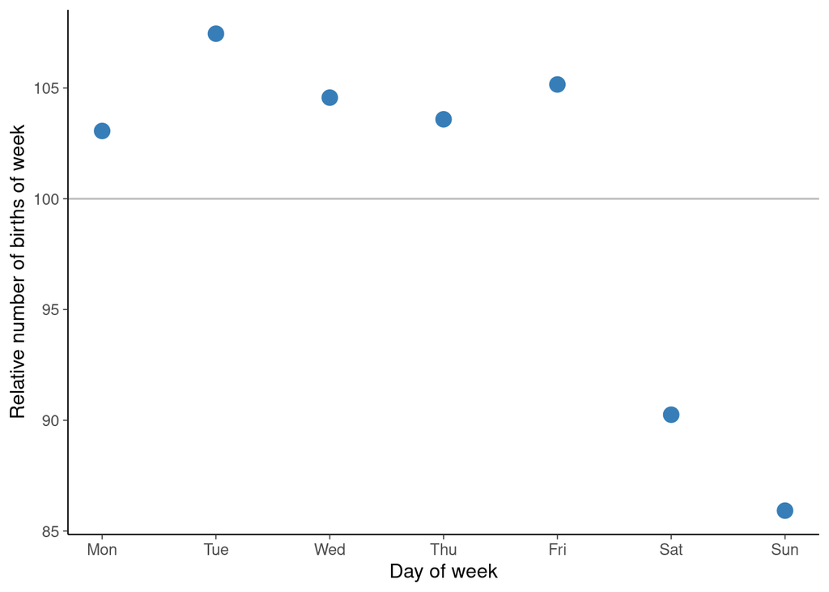

Figure 4

```r
birthdays |>
  group_by(day_of_week) |>
  summarise(meanbirths = mean(births_relative100)) |>
  ggplot(aes(x = day_of_week, y = meanbirths)) +
  geom_point(color = col_data, size = 4) +
  layers_hline100 +
  layers_scale_weekday +
  labs(x = "Day of week", y = "Relative number of births of week")
```

# 3 Previous analyses

We had analysed the same data before (see Gelman et al. (2013)) and thus we already had an idea of what kind of model to use. Previously we used GPstuff software which is Gaussian process specific software for Matlab and Octave. As Stan has aimed to be very generic it can be slower than specialized software for some specific models such as Gaussian processes, but Stan provides more flexibility in the model definition.

Riutort-Mayol et al. (2023) demonstrate Hilbert space approximate basis function approximation of Gaussian processes also for the same birthday data. In the experiments the inference was slower than expected raising suspicion of inefficient model code or bad posterior shape due to bad model specification.

# 4 Workflow for quick iterative model building

Even we have general idea for the model (slow trend, seasonal trend, weekday effect, etc), adding them all at once to the model makes the model complex and difficult to debug and solve the computational problems. It is thus natural to build the model gradually and check that each addition works before adding the next model component. During this iterative model building we want the inference to be fast, but it doesn’t need to be very accurate as long as qualitatively the new model is reasonable. For quick testing and iterative model building we can use optimization, Pathfinder (Zhang et al. 2022) and shorter MCMC chains that we would not recommend for the final inference. Furthermore, in this specific example, the new additions are qualitatively so clear improvements that there is no need for quantitative model comparison whether the additions are ``significant’’ (see also Navarro (2019)) and there is no danger of overfitting (see also McLatchie and Vehtari (2024)). Although there is one part of the model where the data is weakly informative and the prior choices seem to matter and we’ll get back to this and consequences later. Overall we build tens of different models, but illustrate here only the main line.

# 5 Models for relative number of birthdays

As the relative number of births is positive it’s natural to model the logarithm value. The generic form of the models is
$$y \sim \mathrm{normal}(f(x), \sigma),$$
where $f$ is different and gradually more complex function conditional on $x$ that includes running day number, day of year, day of week and eventually some special floating US bank holidays.

## 5.1 Model 1: Slow trend

The model 1 is just the slow trend over the years using Hilbert space basis function approximated Gaussian process
$$\begin{aligned}
f & = \mathrm{intercept} + f_1\\
\mathrm{intercept} & \sim \mathrm{normal}(0,1)\\
f_1 & \sim \mathrm{GP}(0,K_1)
\end{aligned}$$
where GP has exponentiated quadratic covariance function.

In this phase, the code by Riutort-Mayol et al. (2023) was cleaned and written to be more efficient, but only the one GP component was included to make the testing easier. Although the code was made more efficient, the aim wasn’t to make it the fastest possible, as the later model changes may have bigger effect on the performance (it’s good to avoid premature optimization). We also use quite small number of basis functions to make the code run faster, and only later examine more carefully whether the number of basis function is sufficient compared to the posterior of the length scale (see, Riutort-Mayol et al. (2023)).

Compile Stan model gpbf1.stan which includes gpbasisfun_functions.stan.

```r
model1 <- cmdstan_model(stan_file = root("birthdays", "gpbf1.stan"),
                        include_paths = root("birthdays"))
```

Data to be passed to Stan

```r
standata1 <- list(x = birthdays$id,
                  y = log(birthdays$births_relative100),
                  N = length(birthdays$id),
                  c_f1 = 1.5,
                  M_f1 = 20)
```

In this simplest model with just one GP, and as the basis function approximation and priors restrict the complexity of GP, we can safely use optimization to find maximum a posteriori (MAP) estimate get a very quick initial result to check that the model code is computing what we intended (e.g. no NaN, Infs, or nonsensical results). As there are only 24 parameters and 7305 observations it’s likely that the posterior in the unconstrained parameter space is close to normal. To obtain the correct mode in the unconstrained space, we need to call Stan optimizer with option `jacobian = TRUE` (see [Laplace and Jacobian case study](https://users.aalto.fi/~ave/casestudies/Jacobian/jacobian.html) for illustration). Initialization at 0 in unconstrained space is good for most GP models. In this case the optimization takes less than one second while MCMC sampling with default options would have taken several minutes. Although this result can be useful in a quick workflow, the result should not be used as the final result.

```r
tic('Finding MAP for model 1 with optimization')
opt1 <- model1$optimize(data = standata1, init = 0, algorithm = "bfgs",
                        jacobian = TRUE)
```

```r
mytoc()
```

```
Finding MAP for model 1 with optimization took 0.22 sec
```

Check whether parameters have reasonable values

```r
odraws1 <- opt1$draws()
subset(odraws1, variable = c("intercept", "sigma_f1", "lengthscale_f1", "sigma")) |>
  as.data.frame() |>
  tt()
```

| intercept | sigma_f1 | lengthscale_f1 | sigma |
| --- | --- | --- | --- |
| -0.056 | 1.1 | 0.18 | 0.81 |

Compare the model to the data

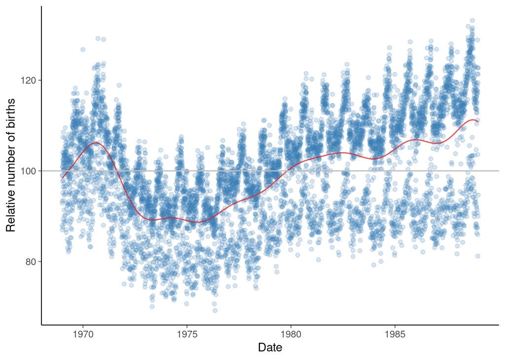

Figure 5

```r
oEf <- exp(as.numeric(subset(odraws1, variable = "f")))
make_pf(birthdays, oEf) + layers_hline100
```

We can obtain a bit more information by making a normal approximation at the mode in the unconstrained parameter space. As Laplace was the first one to use the modal normal approximation, the method is commonly called Laplace method. Stan samples from the normal approximation in the unconstrained space and transforms the obtained draws to the constrained space. Stan’s Laplace method uses `jacobian = TRUE` by default. As we did already optimize, we can pass the optimization result to the Laplace method. With additional 2s we get 400 approximate draws.

```r
tic('Sampling from Laplace approximation of model 1 posterior')
lap1 <- model1$laplace(data = standata1, mode = opt1, draws = 400,
                       refresh = 0)
```

```r
mytoc()
```

Check whether parameters have reasonable values. With Laplace method, we get also some information about the uncertainty in the posterior.

```r
ldraws1 <- lap1$draws()
summarise_draws(subset(ldraws1, variable = c("intercept", "sigma_f1", "lengthscale_f1", "sigma")),
                default_summary_measures()) |>
  tt()
```

| variable | mean | median | sd | mad | q5 | q95 |
| --- | --- | --- | --- | --- | --- | --- |
| intercept | -0.071 | -0.081 | 0.36 | 0.34 | -0.68 | 0.57 |
| sigma_f1 | 1.2 | 1.1 | 0.3 | 0.3 | 0.73 | 1.7 |
| lengthscale_f1 | 0.19 | 0.18 | 0.06 | 0.055 | 0.11 | 0.29 |
| sigma | 0.81 | 0.81 | 0.0065 | 0.0069 | 0.8 | 0.82 |

At the moment, the Laplace method doesn’t automatically run diagnostic to assess the quality of the normal approximation, but we can do it manually by checking the Pareto-$\hat{k}$ diagnostic for the importance sampling weights if the normal approximation would be used as a proposal distribution (Vehtari et al. 2024).

```r
ldraws1 |>
  mutate_variables(lw = lp__ - lp_approx__, w = exp(lw - max(lw))) |>
  subset_draws(variable = "w") |>
  summarise_draws(pareto_diags, .args = list(tail = "right")) |>
  tt()
```

| variable | khat | min_ss | khat_threshold | convergence_rate |
| --- | --- | --- | --- | --- |
| w | 1.6 | Inf | 0.62 | 0 |

Here `khat` is larger than 0.7 indicating that importance sampling even with Pareto smoothing is not able to provide accurate adjustment. `min_ss` indicates how many draws would be needed to get an accurate importance weighting adjustment, and in this case the number is impractically big. Even the Laplace approximation can be useful, this diagnostic shows that we would eventually want to run MCMC for more accurate inference.

After we get the model working using optimization we can compare the result to using short MCMC chains which will also provide us additional information on speed of different code implementations for the same model. We intentionally use just 1/10th length from the usual recommendation, as during the iterative model building a rough results are sufficient. When testing the code we initially used just one chain, but at this point running four chains with four core CPU doesn’t add much to the wall clock time, but gives more information of how easy it is sample from the posterior and can reveal if there are multiple modes. Although the result from short chains can be useful in a quick workflow, the result should not be used as the final result.

```r
tic('MCMC sampling from model 1 posterior')
fit1 <- model1$sample(data = standata1, iter_warmup = 100, iter_sampling = 100,
                      chains = 4, parallel_chains = 4, seed = 3896)
```

```r
mytoc()
```

[output not shown]

Depending on the random seed and luck, we sometimes observed that some of the chains got stuck in different modes. We could see this in high Rhat and low ESS diagnostic values. When updating this case study, we didn’t see multimodality with a few different seeds, but you can see such an example in [Illustration of simple problematic posteriors case study](https://users.aalto.fi/~ave/casestudies/Problems/problems.html)

We can reduce the possibility of getting stuck in minor modes and improve the warmup by using Pathfinder algorithm. Pathfinder runs several optimizations, but chooses a normal approximation along the optimization path that minimizes ``exclusive’’-Kullback-Leibler distance from the approximation to the target posterior. Pathfinder is better than Laplace for highly skewed and funnel like posteriors which are typical for hierarchical model. We get 400 draws from 10 Pathfinder runs.

```r
tic('Sampling from Pathfinder approximation of model 1 posterior')
pth1 <- model1$pathfinder(data = standata1, init = 0.1,
                          num_paths = 10, single_path_draws = 40, draws = 400,
                          history_size = 100, max_lbfgs_iters = 100,
                          refresh = 0)
```

```
Pareto k value (1.6) is greater than 0.7. Importance resampling was not able to improve the approximation, which may indicate that the approximation itself is poor.
Finished in  1.9 seconds.
```

```r
mytoc()
```

Pathfinder provides automatically Pareto-$\hat{k}$ diagnostic which is high, indicating the normal approximation is not good. When Pareto-$\hat{k}$ is very high the Pareto smoothed importance sampling returns fewer distinct draws, and it is useful to check that, too.

```r
pdraws1 <- pth1$draws()
summarise_draws(subset(pdraws1, variable = c("lp__")), n_distinct) |>
  tt()
```

| variable | n_distinct |
| --- | --- |
| lp__ | 24 |

Check whether parameters have reasonable values

```r
summarise_draws(subset(pdraws1, variable = c("intercept", "sigma_f1", "lengthscale_f1", "sigma")),
                default_summary_measures()) |>
  tt()
```

| variable | mean | median | sd | mad | q5 | q95 |
| --- | --- | --- | --- | --- | --- | --- |
| intercept | -0.014 | -0.054 | 0.063 | 0 | -0.054 | 0.097 |
| sigma_f1 | 0.98 | 1 | 0.052 | 0 | 0.87 | 1 |
| lengthscale_f1 | 0.22 | 0.22 | 0.011 | 0 | 0.22 | 0.24 |
| sigma | 0.81 | 0.81 | 0.005 | 0 | 0.8 | 0.81 |

In this case, we get more than one distinct draw, and the draws do have reasonable values and we get also some information about the uncertainty in the posterior (as with Laplace method). We use only `default_summary_measures()` as the MCMC diagnostics are not useful for Pathfinder draws.

The Pathfinder draws can be used to initialize MCMC as they are likely to be closer to where most of the posterior mass is than the default Stan initialization using uniform random draws from -2 to 2 (in unconstrained space).

```r
tic('MCMC sampling from model 1 posterior with Pathfinder initialization')
fit1 <- model1$sample(data = standata1, iter_warmup = 100, iter_sampling = 100,
                      chains = 4, parallel_chains = 4,
                      init = pth1)
```

```r
mytoc()
```

In many of the following short MCMC samplings we get some or many divergences and usually very large number of treedepth exceedences. Divergences indicate possible bias and should be eventually investigated carefully. Treedepth exceedences indicate strong posterior dependencies and slow mixing and sometimes the posterior can be much improved by changing the parameterization or priors, but as the treedepth exceedences don’t indicate bias there is no need for more careful analysis if the resulting ESS and MCSE values are good for the purpose in hand. We’ll come back later to more careful analysis of the final models.

```r
draws1 <- fit1$draws()
summarise_draws(subset(draws1, variable = c("intercept", "sigma_f1", "lengthscale_f1", "sigma"))) |>
  tt()
```

| variable | mean | median | sd | mad | q5 | q95 | rhat | ess_bulk | ess_tail |
| --- | --- | --- | --- | --- | --- | --- | --- | --- | --- |
| intercept | 0.018 | 0.026 | 0.22 | 0.23 | -0.31 | 0.36 | 1 | 275 | 262 |
| sigma_f1 | 0.58 | 0.57 | 0.12 | 0.1 | 0.42 | 0.76 | 1 | 179 | 225 |
| lengthscale_f1 | 0.22 | 0.23 | 0.034 | 0.032 | 0.16 | 0.27 | 1 | 207 | 314 |
| sigma | 0.81 | 0.81 | 0.0068 | 0.0072 | 0.8 | 0.82 | 1 | 454 | 375 |

Trace plot shows slow mixing but no multimodality.

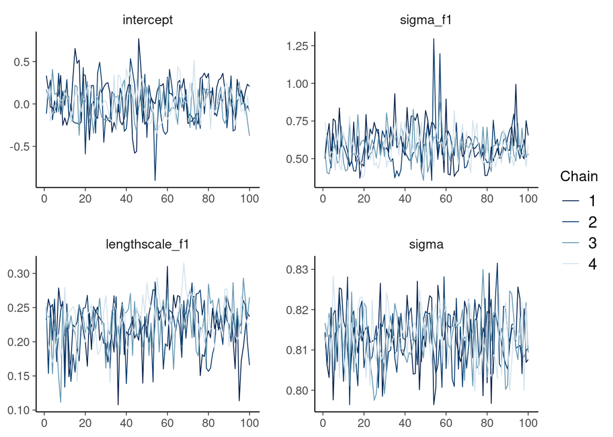

Figure 6

```r
mcmc_trace(draws1, regex_pars = c("intercept", "sigma_f1", "lengthscale_f1", "sigma"))
```

The model result from short MCMC chains looks very similar to the optimization result.

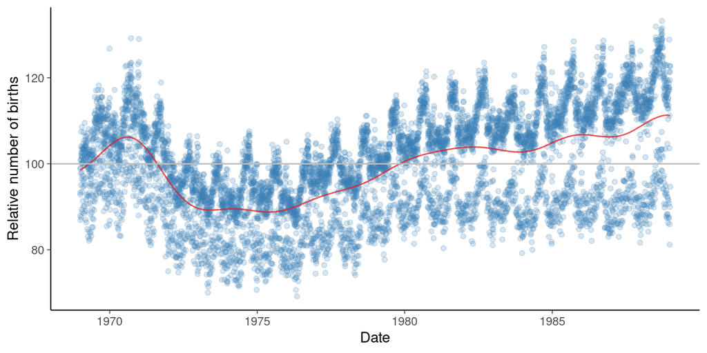

Figure 7

```r
draws1 <- as_draws_matrix(draws1)
Ef <- exp(apply(subset(draws1, variable = "f"), 2, median))
make_pf(birthdays, Ef) + layers_hline100
```

If we compare the result from short sampling to optimizing, we don’t see practical difference in the predictions (although we see later more differences between optimization and MCMC).

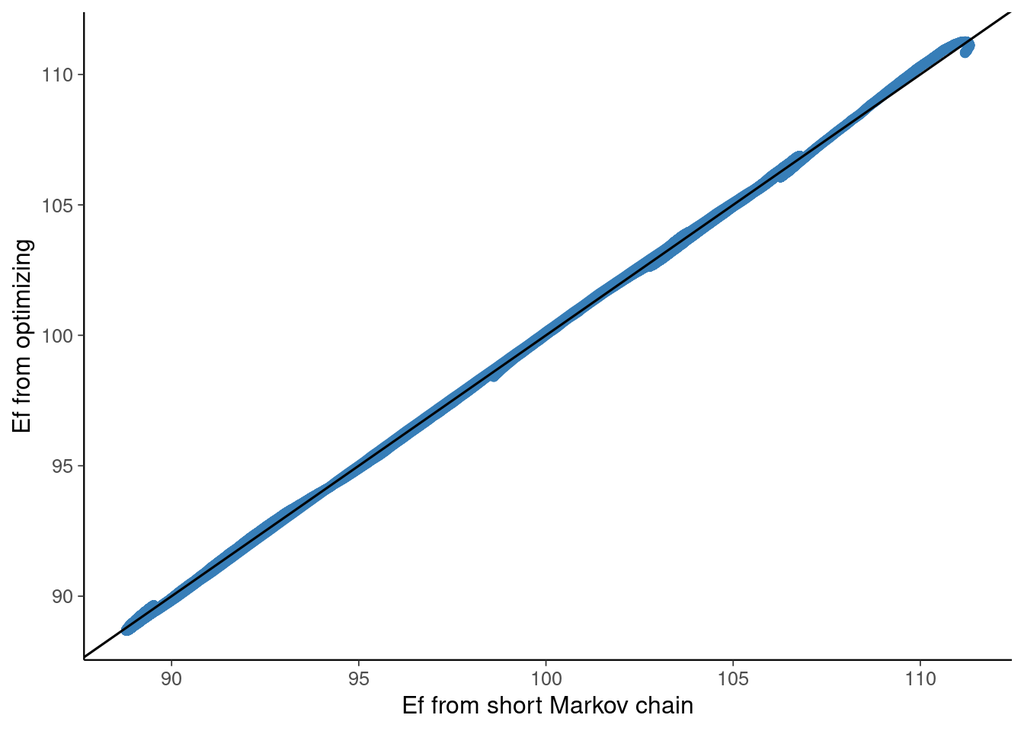

Figure 8

```r
birthdays |>
  mutate(Ef = Ef,
         oEf = oEf) |>
  ggplot(aes(x = Ef, y = oEf)) +
  geom_point(color = col_data) +
  geom_abline() +
  labs(x = "Ef from short Markov chain", y = "Ef from optimizing")
```

After the first version of this notebook, [Nikolas Siccha examined more carefully the posterior correlations](https://github.com/nsiccha/birthday) and noticed strong correlation between intercept and the first basis function. Stan’s dynamic HMC is so efficient that the inference is successful anyway. Nikolas suggested removing the intercept term. The intercept term is not necessarily needed as the data has been centered. We test a model without the explicit intercept term.

Compile Stan model gpbf1b.stan

```r
model1b <- cmdstan_model(stan_file = root("birthdays", "gpbf1b.stan"),
                         include_paths = root("birthdays"))
```

First run Pathfinder

```r
tic('Sampling from Pathfinder approximation of model 1b posterior')
pth1b <- model1b$pathfinder(data = standata1, init = 0.1,
                            num_paths = 10, single_path_draws = 40, draws = 400,
                            history_size = 50, max_lbfgs_iters = 100,
                            refresh = 0)
```

```
Pareto k value (1.6) is greater than 0.7. Importance resampling was not able to improve the approximation, which may indicate that the approximation itself is poor.
Finished in  1.8 seconds.
```

```r
mytoc()
```

[output not shown]

Then sample using the Pathfinder initialization.

```r
tic('MCMC sampling from model 1b posterior with Pathfinder initialization')
fit1b <- model1b$sample(data = standata1, iter_warmup = 100, iter_sampling = 100,
                        chains = 4, parallel_chains = 4,
                        init = pth1b)
```

```r
mytoc()
```

The sampling is even faster, indicating that the strong posterior correlation in the first model was causing troubles for the adaptation in the short warmup.

```r
draws1b <- fit1b$draws()
summarise_draws(subset(draws1b, variable = c("sigma_f1", "lengthscale_f1", "sigma"))) |>
  tt()
```

| variable | mean | median | sd | mad | q5 | q95 | rhat | ess_bulk | ess_tail |
| --- | --- | --- | --- | --- | --- | --- | --- | --- | --- |
| sigma_f1 | 0.58 | 0.56 | 0.12 | 0.1 | 0.42 | 0.82 | 1 | 107 | 193 |
| lengthscale_f1 | 0.23 | 0.23 | 0.038 | 0.036 | 0.17 | 0.29 | 1 | 184 | 249 |
| sigma | 0.81 | 0.81 | 0.007 | 0.0074 | 0.8 | 0.82 | 1 | 430 | 313 |

Examining the trace plots don’t show multimodality

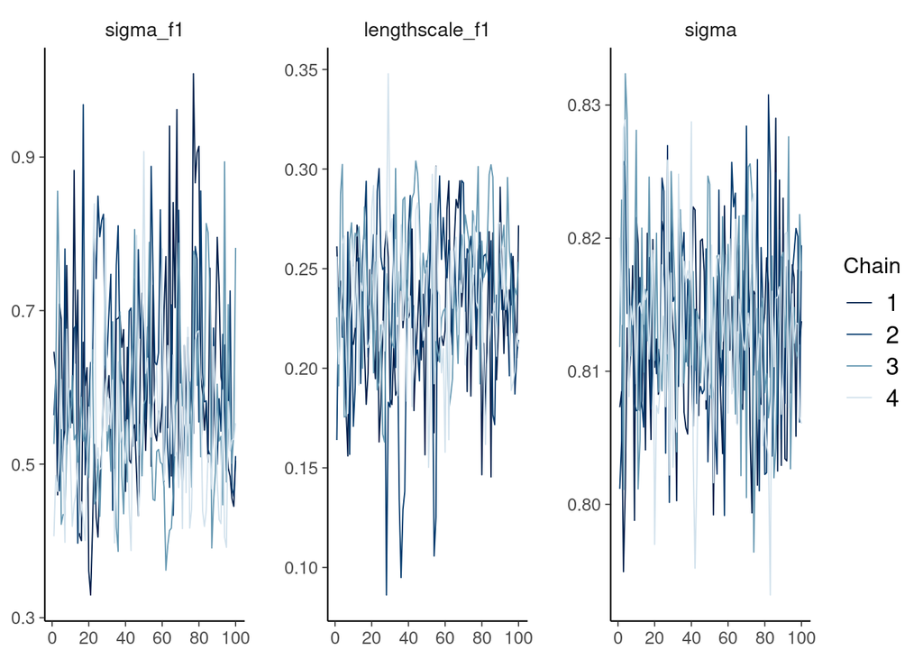

Figure 9

```r
mcmc_trace(draws1b, regex_pars = c("sigma_f1", "lengthscale_f1", "sigma"))
```

We drop global intercept from the rest of the models, but continue using Pathfinder to initialize the sampling.

Compare the mean and sd of parameters from Pathfinder and MCMC. When the normal approximation is not good, Pathfinder tends to underestimate the posterior variance, which makes it less useful for setting the initial mass matrix. Thus, here we are using Pathfinder only to get initial values for MCMC.

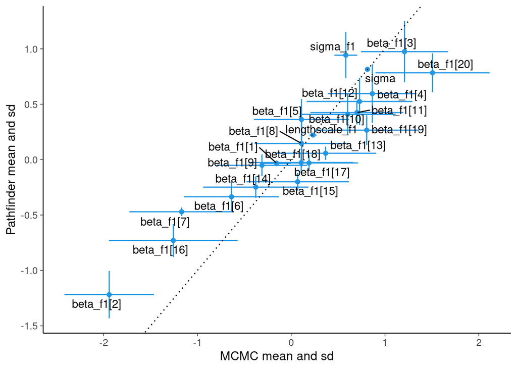

Figure 10

```r
variables <- names(model1b$variables()$parameters)
sp <- summarise_draws(subset(pth1b$draws(), variable = variables))
sm <- summarise_draws(subset(draws1b, variable = variables))
make_pth_vs_fit(sm, sp)
```

## 5.2 Model 2: Slow trend + yearly seasonal trend

The model 2 adds yearly seasonal trend using GP with periodic covariance function.
$$\begin{aligned}
f & = \mathrm{intercept} + f_1 + f_2 \\
\mathrm{intercept} & \sim \mathrm{normal}(0,1)\\
f_1 & \sim \mathrm{GP}(0,K_1)\\
f_2 & \sim \mathrm{GP}(0,K_2)
\end{aligned}$$
where the first GP uses the exponentiated quadratic covariance function, and the second one a periodic covariance function. Most years have 365 calendar days and every four years (during the data range) there are 366 days, and thus we simplify and use period of 365.25 for the periodic component,

The first version of model 2 with the added periodic component following Riutort-Mayol:2023:HSGP turned out be very slow. With the default MCMC options the inference would have taken hours, but with the short chains it was possible to infer that something has to be wrong. The model output was sensible, but diagnostics indicated very slow mixing. By more careful examination of the model it turned out that the periodic component was including another intercept term and with two intercept terms their sum was well informed by the data, but individually they were not well informed and thus the posteriors were wide, which lead to very slow mixing. This bad model is not shown here, but the optimization, short MCMC chains and sampling diagnostic tools were crucial for fast experimentation and solving the problem.

Compile Stan model 2 (the fixed version) gpbf2.stan

```r
model2 <- cmdstan_model(stan_file = root("birthdays", "gpbf2.stan"),
                        include_paths = root("birthdays"))
```

Data to be passed to Stan

```r
standata2 <- list(x = birthdays$id,
                  y = log(birthdays$births_relative100),
                  N = length(birthdays$id),
                  c_f1 = 1.5,
                  M_f1 = 20,
                  J_f2 = 20)
```

Pathfinder is faster than sampling (although this result can be useful in a quick workflow, the result should not be used as the final result).

```r
tic('Sampling from Pathfinder approximation of model 2 posterior')
pth2 <- model2$pathfinder(data = standata2, init = 0.1,
                          num_paths = 10, single_path_draws = 40, draws = 400,
                          history_size = 50, max_lbfgs_iters = 100,
                          refresh = 0)
```

```
Pareto k value (3) is greater than 0.7. Importance resampling was not able to improve the approximation, which may indicate that the approximation itself is poor.
Finished in  5.8 seconds.
```

```r
mytoc()
```

Pareto-$\hat{k}$ is even higher, but the Pathfinder draws are likely to be useful for quick analysis and initialization of MCMC sampling.

Check whether parameters have reasonable values

```r
pdraws2 <- pth2$draws()
summarise_draws(subset(pdraws2, variable = c("lp__")), n_distinct) |>
  tt()
```

| variable | n_distinct |
| --- | --- |
| lp__ | 12 |

```r
summarise_draws(subset(pdraws2, variable = c("sigma_", "lengthscale_", "sigma"), regex = TRUE),
                default_summary_measures()) |>
  tt()
```

| variable | mean | median | sd | mad | q5 | q95 |
| --- | --- | --- | --- | --- | --- | --- |
| sigma_f1 | 0.8 | 0.91 | 0.14 | 0.027 | 0.65 | 0.93 |
| sigma_f2 | 0.91 | 0.96 | 0.075 | 0.0033 | 0.82 | 0.96 |
| lengthscale_f1 | 0.22 | 0.22 | 0.024 | 0.037 | 0.19 | 0.25 |
| lengthscale_f2 | 0.17 | 0.15 | 0.022 | 0.0017 | 0.15 | 0.2 |
| sigma | 0.76 | 0.76 | 0.0041 | 0.0037 | 0.76 | 0.77 |

Compare the model to the data

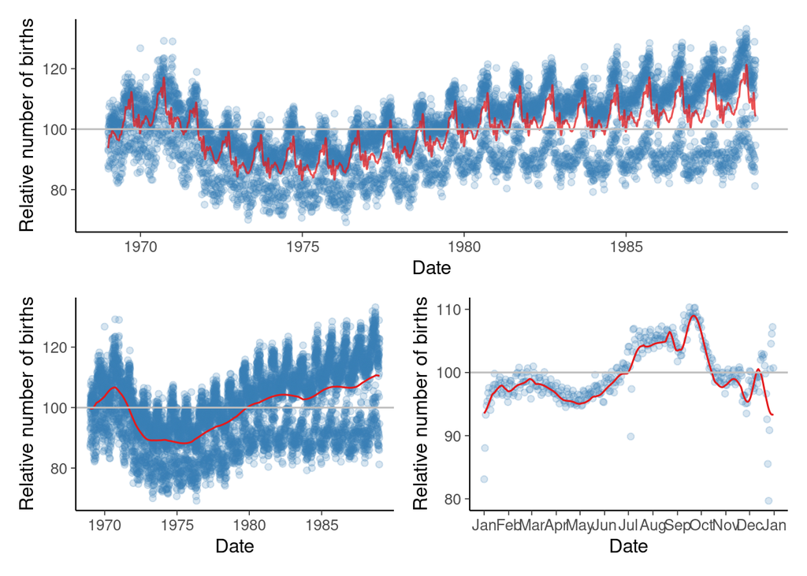

Figure 11

```r
draws2 <- as_draws_matrix(pdraws2)
Ef <- exp(apply(subset(draws2, variable = "f"), 2, median))
Ef1 <- apply(subset(draws2, variable = "f1"), 2, median)
Ef1 <- exp(Ef1 - mean(Ef1) + mean(log(birthdays$births_relative100)))
Ef2 <- apply(subset(draws2, variable = "f2"), 2, median)
Ef2 <- exp(Ef2 - mean(Ef2) + mean(log(birthdays$births_relative100)))
pf  <- make_pf(birthdays, Ef) + layers_hline100
pf1 <- make_pf1(birthdays, Ef1)
pf2 <- make_pf2(birthdays, Ef2)
compose_3panel(pf, pf1, pf2)
```

Even Pareto-$\hat{k}$ indicated that Pathfinder approximation was not good enough to be reliably adjusted using importance sampling, the draws produce sensible model predictions.

Sample short chains using the Pathfinder result as initial values (although the result from short chains can be useful in a quick workflow, the result should not be used as the final result).

```r
tic('MCMC sampling from model 2 posterior with Pathfinder initialization')
fit2 <- model2$sample(data = standata2, iter_warmup = 100, iter_sampling = 100,
                      chains = 4, parallel_chains = 4,
                      init = pth2)
```

```r
mytoc()
```

Check whether parameters have reasonable values

```r
draws2 <- fit2$draws()
summarise_draws(subset(draws2, variable = c("sigma_", "lengthscale_", "sigma"), regex = TRUE)) |>
  tt()
```

| variable | mean | median | sd | mad | q5 | q95 | rhat | ess_bulk | ess_tail |
| --- | --- | --- | --- | --- | --- | --- | --- | --- | --- |
| sigma_f1 | 0.58 | 0.56 | 0.14 | 0.13 | 0.41 | 0.81 | 1 | 206 | 243 |
| sigma_f2 | 0.3 | 0.29 | 0.052 | 0.051 | 0.23 | 0.39 | 1 | 225 | 324 |
| lengthscale_f1 | 0.21 | 0.22 | 0.041 | 0.038 | 0.14 | 0.27 | 1 | 306 | 275 |
| lengthscale_f2 | 0.25 | 0.25 | 0.023 | 0.023 | 0.21 | 0.29 | 1 | 212 | 320 |
| sigma | 0.75 | 0.75 | 0.0069 | 0.0074 | 0.74 | 0.76 | 1 | 363 | 276 |

Compare the model to the data

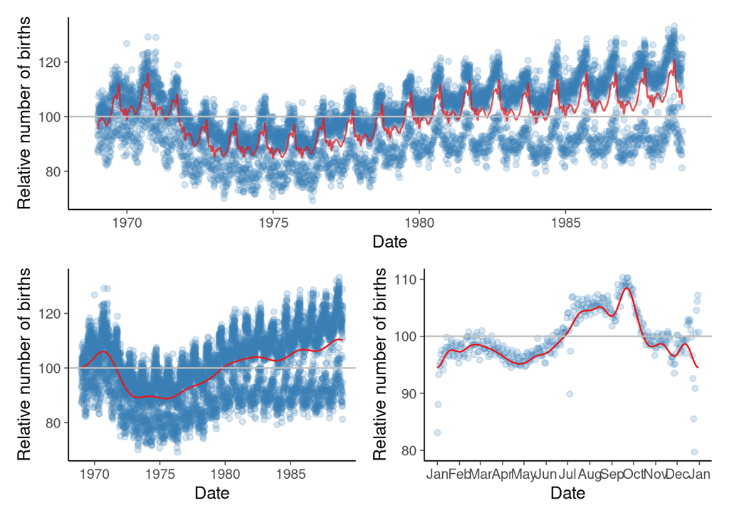

Figure 12

```r
draws2 <- as_draws_matrix(draws2)
Ef <- exp(apply(subset(draws2, variable = "f"), 2, median))
Ef1 <- apply(subset(draws2, variable = "f1"), 2, median)
Ef1 <- exp(Ef1 - mean(Ef1) + mean(log(birthdays$births_relative100)))
Ef2 <- apply(subset(draws2, variable = "f2"), 2, median)
Ef2 <- exp(Ef2 - mean(Ef2) + mean(log(birthdays$births_relative100)))
pf  <- make_pf(birthdays, Ef) + layers_hline100
pf1 <- make_pf1(birthdays, Ef1)
pf2 <- make_pf2(birthdays, Ef2)
compose_3panel(pf, pf1, pf2)
```

Seasonal component has reasonable fit to the data.

Compare the mean and sd of parameters from Pathfinder and MCMC.

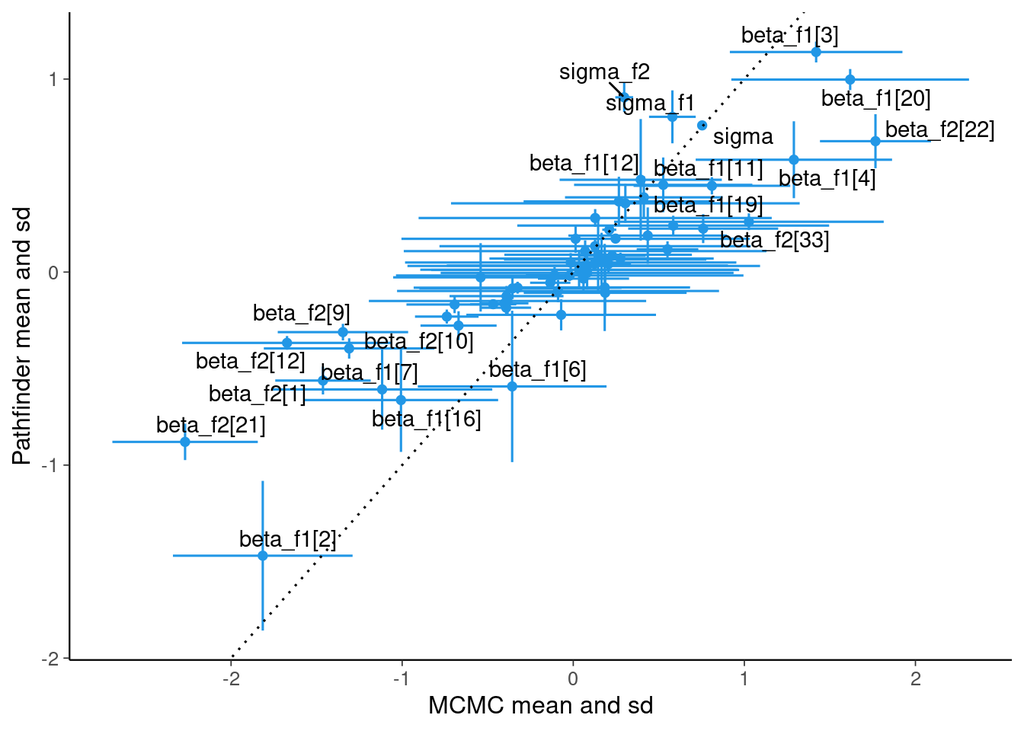

Figure 13

```r
variables <- names(model2$variables()$parameters)
sp <- summarise_draws(subset(pdraws2, variable = variables))
sm <- summarise_draws(subset(draws2, variable = variables))
make_pth_vs_fit(sm, sp)
```

## 5.3 Model 3: Slow trend + yearly seasonal trend + day of week

Based on the quick plotting of the data above, day of week has a clear effect and there are less babies born on Saturday and Sunday. This can be taken into account with simple additive coefficients. We fix the effect of Monday to 0 and have additional coefficients for other weekdays.
$$\begin{aligned}
f & = \mathrm{intercept} + f_1 + f_2 + \beta_{\text{day of week}} \\
\mathrm{intercept} & \sim \mathrm{normal}(0,1)\\
f_1 & \sim \mathrm{GP}(0,K_1)\\
f_2 & \sim \mathrm{GP}(0,K_2)\\
\beta_{\text{day of week}} & = 0 \quad \text{if day of week is Monday}\\
\beta_{\text{day of week}} & \sim \mathrm{normal}(0,1) \quad \text{if day of week is not Monday}
\end{aligned}$$

Compile Stan model 3 gpbf3.stan

```r
model3 <- cmdstan_model(stan_file = root("birthdays", "gpbf3.stan"),
                        include_paths = root("birthdays"))
```

Data to be passed to Stan

```r
standata3 <- list(x = birthdays$id,
                  y = log(birthdays$births_relative100),
                  N = length(birthdays$id),
                  c_f1 = 1.5, # factor c of basis functions for GP for f1
                  M_f1 = 20,  # number of basis functions for GP for f1
                  J_f2 = 20,  # number of basis functions for periodic f2
                  day_of_week = birthdays$day_of_week)
```

Pathfinder is faster than sampling (although this result can be useful in a quick workflow, the result should not be used as the final result).

```r
tic('Sampling from Pathfinder approximation of model 3 posterior')
pth3 <- model3$pathfinder(data = standata3, init = 0.1,
                          num_paths = 10, single_path_draws = 40, draws = 400,
                          history_size = 50, max_lbfgs_iters = 100,
                          refresh = 0)
```

```
Pareto k value (2.4) is greater than 0.7. Importance resampling was not able to improve the approximation, which may indicate that the approximation itself is poor.
Finished in  5.6 seconds.
```

```r
mytoc()
```

Check whether parameters have reasonable values

```r
pdraws3 <- pth3$draws()
summarise_draws(subset(pdraws3, variable = c("lp__")), n_distinct) |>
  tt()
```

| variable | n_distinct |
| --- | --- |
| lp__ | 8 |

```r
summarise_draws(subset(pdraws3, variable = c("sigma_", "lengthscale_", "sigma", "beta_f3"), regex = TRUE),
                default_summary_measures()) |>
  tt()
```

| variable | mean | median | sd | mad | q5 | q95 |
| --- | --- | --- | --- | --- | --- | --- |
| sigma_f1 | 0.62 | 0.62 | 0.026 | 0 | 0.62 | 0.62 |
| sigma_f2 | 0.74 | 0.74 | 0.032 | 0 | 0.68 | 0.74 |
| lengthscale_f1 | 0.18 | 0.18 | 0.003 | 0 | 0.17 | 0.18 |
| lengthscale_f2 | 0.17 | 0.18 | 0.0042 | 0 | 0.16 | 0.18 |
| sigma | 0.33 | 0.33 | 0.00063 | 0 | 0.33 | 0.33 |
| beta_f3[1] | 0.35 | 0.36 | 0.0037 | 0 | 0.34 | 0.36 |
| beta_f3[2] | 0.12 | 0.12 | 0.0019 | 0 | 0.12 | 0.12 |
| beta_f3[3] | 0.044 | 0.044 | 0.003 | 0 | 0.044 | 0.052 |
| beta_f3[4] | 0.15 | 0.15 | 0.0053 | 0 | 0.15 | 0.15 |
| beta_f3[5] | -1.1 | -1.1 | 0.0068 | 0 | -1.1 | -1.1 |
| beta_f3[6] | -1.5 | -1.5 | 0.006 | 0 | -1.5 | -1.5 |

Compare the model to the data

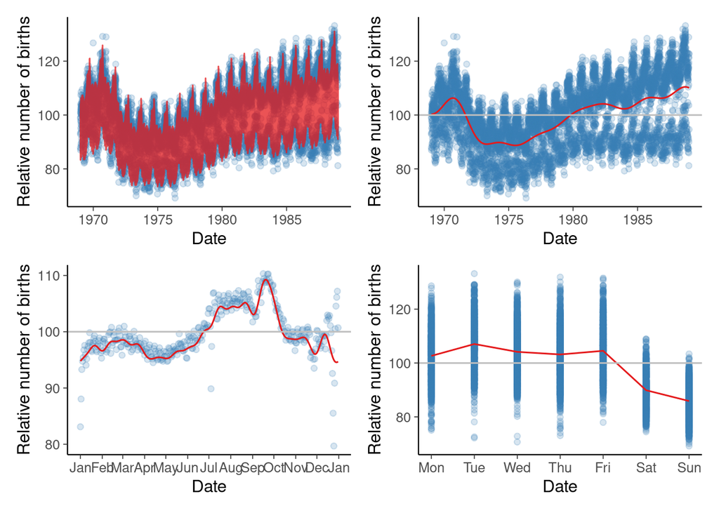

Figure 14

```r
draws3 <- as_draws_matrix(pdraws3)
Ef <- exp(apply(subset(draws3, variable = "f"), 2, median))
Ef1 <- apply(subset(draws3, variable = "f1"), 2, median)
Ef1 <- exp(Ef1 - mean(Ef1) + mean(log(birthdays$births_relative100)))
Ef2 <- apply(subset(draws3, variable = "f2"), 2, median)
Ef2 <- exp(Ef2 - mean(Ef2) + mean(log(birthdays$births_relative100)))
Ef_day_of_week <- apply(subset(draws3, variable = "f_day_of_week"), 2, median)
Ef_day_of_week <- exp(Ef_day_of_week - mean(Ef_day_of_week) + mean(log(birthdays$births_relative100)))
pf  <- make_pf(birthdays, Ef)
pf1 <- make_pf1(birthdays, Ef1)
pf2 <- make_pf2(birthdays, Ef2)
pf3 <- make_pf3(birthdays, Ef_day_of_week)
compose_4panel(pf, pf1, pf2, pf3)
```

Sample short chains using the Pathfinder result as initial values (although the result from short chains can be useful in a quick workflow, the result should not be used as the final result).

```r
tic('MCMC sampling from model 3 posterior with Pathfinder initialization')
fit3 <- model3$sample(data = standata3, iter_warmup = 100, iter_sampling = 100,
                      chains = 4, parallel_chains = 4,
                      init = pth3)
```

```r
mytoc()
```

Check whether parameters have reasonable values

```r
draws3 <- fit3$draws()
summarise_draws(subset(draws3, variable = c("sigma_", "lengthscale_", "sigma"), regex = TRUE)) |>
  tt()
```

| variable | mean | median | sd | mad | q5 | q95 | rhat | ess_bulk | ess_tail |
| --- | --- | --- | --- | --- | --- | --- | --- | --- | --- |
| sigma_f1 | 0.62 | 0.6 | 0.14 | 0.13 | 0.45 | 0.91 | 1 | 214 | 298 |
| sigma_f2 | 0.29 | 0.29 | 0.046 | 0.04 | 0.23 | 0.37 | 1 | 219 | 207 |
| lengthscale_f1 | 0.21 | 0.21 | 0.04 | 0.034 | 0.13 | 0.26 | 1 | 309 | 277 |
| lengthscale_f2 | 0.21 | 0.21 | 0.018 | 0.017 | 0.18 | 0.24 | 1 | 187 | 228 |
| sigma | 0.33 | 0.33 | 0.0028 | 0.0028 | 0.33 | 0.34 | 1 | 337 | 196 |

```r
summarise_draws(subset(draws3, variable = c("beta_f3"))) |>
  tt()
```

| variable | mean | median | sd | mad | q5 | q95 | rhat | ess_bulk | ess_tail |
| --- | --- | --- | --- | --- | --- | --- | --- | --- | --- |
| beta_f3[1] | 0.36 | 0.36 | 0.015 | 0.015 | 0.33 | 0.38 | 1 | 440 | 314 |
| beta_f3[2] | 0.13 | 0.13 | 0.016 | 0.017 | 0.099 | 0.15 | 1 | 383 | 415 |
| beta_f3[3] | 0.041 | 0.042 | 0.015 | 0.015 | 0.016 | 0.064 | 1 | 432 | 351 |
| beta_f3[4] | 0.17 | 0.17 | 0.015 | 0.015 | 0.15 | 0.2 | 1 | 381 | 300 |
| beta_f3[5] | -1.1 | -1.1 | 0.015 | 0.016 | -1.1 | -1.1 | 1 | 405 | 410 |
| beta_f3[6] | -1.5 | -1.5 | 0.016 | 0.018 | -1.5 | -1.5 | 1 | 403 | 341 |

Compare the model to the data

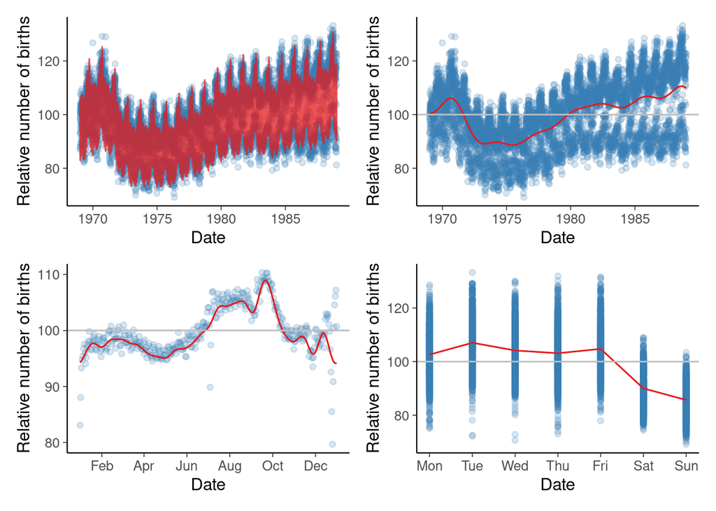

Figure 15

```r
draws3 <- as_draws_matrix(draws3)
Ef <- exp(apply(subset(draws3, variable = "f"), 2, median))
Ef1 <- apply(subset(draws3, variable = "f1"), 2, median)
Ef1 <- exp(Ef1 - mean(Ef1) + mean(log(birthdays$births_relative100)))
Ef2 <- apply(subset(draws3, variable = "f2"), 2, median)
Ef2 <- exp(Ef2 - mean(Ef2) + mean(log(birthdays$births_relative100)))
Ef_day_of_week <- apply(subset(draws3, variable = "f_day_of_week"), 2, median)
Ef_day_of_week <- exp(Ef_day_of_week - mean(Ef_day_of_week) + mean(log(birthdays$births_relative100)))
pf  <- make_pf(birthdays, Ef)
pf1 <- make_pf1(birthdays, Ef1)
pf2 <- make_pf2(birthdays, Ef2, date_breaks = "2 month")
pf3 <- make_pf3(birthdays, Ef_day_of_week)
compose_4panel(pf, pf1, pf2, pf3)
```

Weekday effects are easy to estimate as there are about thousand observations per weekday.

Compare the mean and sd of parameters from Pathfinder and MCMC.

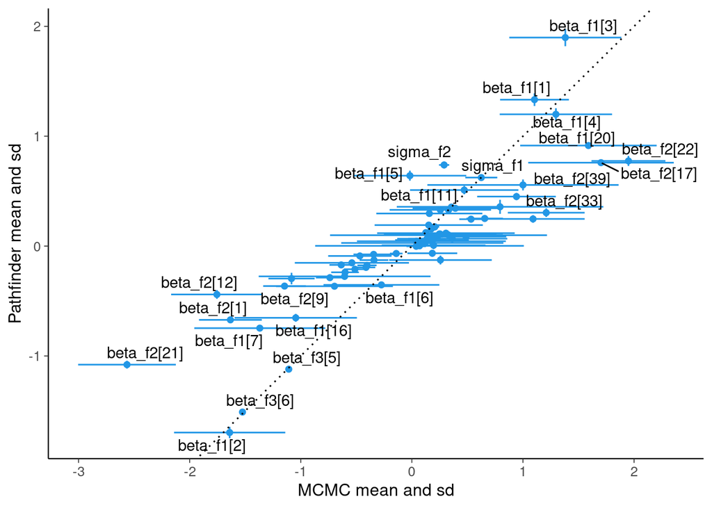

Figure 16

```r
variables <- names(model3$variables()$parameters)
sp <- summarise_draws(subset(pdraws3, variable = variables))
sm <- summarise_draws(subset(draws3, variable = variables))
make_pth_vs_fit(sm, sp)
```

## 5.4 Model 4: long term smooth + seasonal + weekday with increasing magnitude

Looking at the time series of whole data we see the dots representing the daily values forming three branches that are getting further away from each other. In previous analysis (Gelman et al. 2013) we also had a model component allowing gradually changing effect for day of week and did observe that the effect of Saturday and Sunday did get stronger in time. The next model includes time dependent magnitude component for the day of week effect.
$$\begin{aligned}
f & = \mathrm{intercept} + f_1 + f_2 + \exp(g_3)\beta_{\text{day of week}} \\
\mathrm{intercept} & \sim \mathrm{normal}(0,1)\\
f_1 & \sim \mathrm{GP}(0,K_1)\\
f_2 & \sim \mathrm{GP}(0,K_2)\\
g_3 & \sim \mathrm{GP}(0,K_3)\\
\beta_{\text{day of week}} = & 0 \quad \text{if day of week is Monday}\\
\beta_{\text{day of week}} & \sim \mathrm{normal}(0,1) \quad \text{if day of week is not Monday}
\end{aligned}$$
The magnitude of the weekday effect is modelled with $\exp(g_3)$, where $g_3$ has GP prior with zero mean and exponentiated quadratic covariance function.

Compile Stan model 4 gpbf4.stan

```r
model4 <- cmdstan_model(stan_file = root("birthdays", "gpbf4.stan"),
                        include_paths = root("birthdays"))
```

Data to be passed to Stan

```r
standata4 <- list(x = birthdays$id,
                  y = log(birthdays$births_relative100),
                  N = length(birthdays$id),
                  c_f1 = 1.5, # factor c of basis functions for GP for f1
                  M_f1 = 20,  # number of basis functions for GP for f1
                  J_f2 = 20,  # number of basis functions for periodic f2
                  c_g3 = 1.5, # factor c of basis functions for GP for g3
                  M_g3 = 5,   # number of basis functions for GP for g3
                  day_of_week = birthdays$day_of_week)
```

Pathfinder is faster than sampling (although this result can be useful in a quick workflow, the result should not be used as the final result).

```r
tic('Sampling from Pathfinder approximation of model 4 posterior')
pth4 <- model4$pathfinder(data = standata4, init = 0.1,
                          num_paths = 10, single_path_draws = 40, draws = 400,
                          history_size = 50, max_lbfgs_iters = 100,
                          refresh = 0)
```

```
Pareto k value (2.4) is greater than 0.7. Importance resampling was not able to improve the approximation, which may indicate that the approximation itself is poor.
Finished in  6.4 seconds.
```

```r
mytoc()
```

Check whether parameters have reasonable values

```r
pdraws4 <- pth4$draws()
summarise_draws(subset(pdraws4, variable = c("lp__")), n_distinct) |>
  tt()
```

| variable | n_distinct |
| --- | --- |
| lp__ | 10 |

```r
summarise_draws(subset(pdraws4, variable = c("sigma_", "lengthscale_", "sigma", "beta_f3"), regex = TRUE),
                default_summary_measures()) |>
  tt()
```

| variable | mean | median | sd | mad | q5 | q95 |
| --- | --- | --- | --- | --- | --- | --- |
| sigma_f1 | 0.69 | 0.69 | 0.042 | 0 | 0.64 | 0.73 |
| sigma_f2 | 0.72 | 0.7 | 0.041 | 0 | 0.66 | 0.77 |
| sigma_g3 | 0.28 | 0.28 | 0.0056 | 0 | 0.27 | 0.28 |
| lengthscale_f1 | 0.2 | 0.2 | 0.0052 | 0 | 0.19 | 0.2 |
| lengthscale_f2 | 0.17 | 0.16 | 0.008 | 0 | 0.16 | 0.18 |
| lengthscale_g3 | 0.71 | 0.72 | 0.015 | 0 | 0.68 | 0.72 |
| sigma | 0.31 | 0.31 | 0.0016 | 0 | 0.31 | 0.31 |
| beta_f3[1] | 0.37 | 0.37 | 0.0051 | 0 | 0.37 | 0.38 |
| beta_f3[2] | 0.14 | 0.14 | 0.0021 | 0 | 0.13 | 0.14 |
| beta_f3[3] | 0.047 | 0.043 | 0.0077 | 0 | 0.043 | 0.063 |
| beta_f3[4] | 0.18 | 0.18 | 0.0045 | 0 | 0.18 | 0.19 |
| beta_f3[5] | -1.2 | -1.2 | 0.016 | 0 | -1.2 | -1.1 |
| beta_f3[6] | -1.6 | -1.6 | 0.013 | 0 | -1.6 | -1.6 |

Compare the model to the data

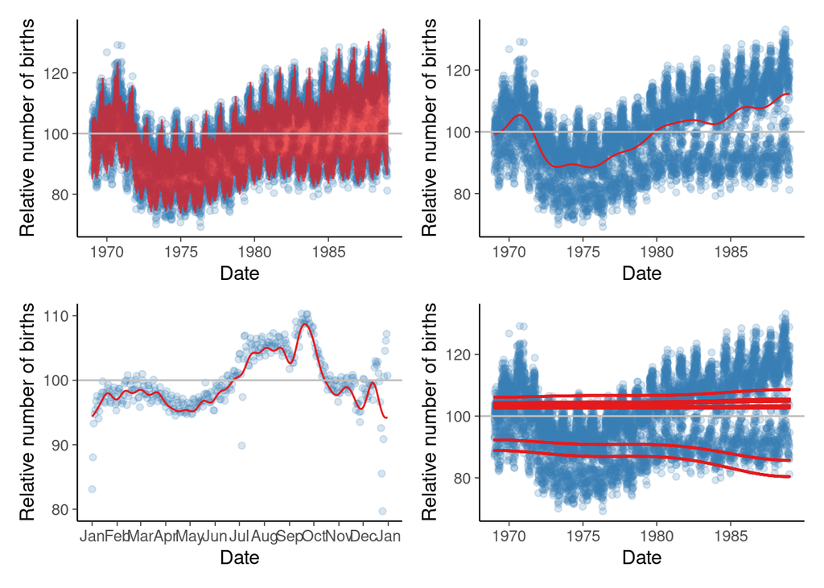

Figure 17

```r
draws4 <- as_draws_matrix(pdraws4)
Ef <- exp(apply(subset(draws4, variable = "f"), 2, median))
Ef1 <- apply(subset(draws4, variable = "f1"), 2, median)
Ef1 <- exp(Ef1 - mean(Ef1) + mean(log(birthdays$births_relative100)))
Ef2 <- apply(subset(draws4, variable = "f2"), 2, median)
Ef2 <- exp(Ef2 - mean(Ef2) + mean(log(birthdays$births_relative100)))
Ef_day_of_week <- apply(subset(draws4, variable = "f_day_of_week"), 2, median)
Ef_day_of_week <- exp(Ef_day_of_week - mean(Ef_day_of_week) + mean(log(birthdays$births_relative100)))
Ef3 <- apply(subset(draws4, variable = "f3"), 2, median)
Ef3 <- exp(Ef3 - mean(Ef3) + mean(log(birthdays$births_relative100)))
pf   <- make_pf(birthdays, Ef) + layers_hline100
pf1  <- make_pf1(birthdays, Ef1)
pf2  <- make_pf2(birthdays, Ef2)
pf3b <- make_pf3b(birthdays, Ef3)
compose_4panel(pf, pf1, pf2, pf3b)
```

Sample short chains using the Pathfinder result as initial values (although the result from short chains can be useful in a quick workflow, the result should not be used as the final result).

```r
tic('MCMC sampling from model 4 posterior with Pathfinder initialization')
fit4 <- model4$sample(data = standata4, iter_warmup = 100, iter_sampling = 100,
                      chains = 4, parallel_chains = 4,
                      init = pth4)
```

```r
mytoc()
```

Check whether parameters have reasonable values

```r
draws4 <- fit4$draws()
summarise_draws(subset(draws4, variable = c("sigma_", "lengthscale_", "sigma"), regex = TRUE)) |>
  tt()
```

| variable | mean | median | sd | mad | q5 | q95 | rhat | ess_bulk | ess_tail |
| --- | --- | --- | --- | --- | --- | --- | --- | --- | --- |
| sigma_f1 | 0.66 | 0.64 | 0.15 | 0.14 | 0.44 | 0.96 | 1 | 242 | 267 |
| sigma_f2 | 0.29 | 0.28 | 0.048 | 0.044 | 0.22 | 0.37 | 1 | 217 | 254 |
| sigma_g3 | 0.19 | 0.19 | 0.041 | 0.04 | 0.13 | 0.27 | 1 | 479 | 262 |
| lengthscale_f1 | 0.21 | 0.21 | 0.039 | 0.031 | 0.14 | 0.26 | 1 | 275 | 104 |
| lengthscale_f2 | 0.2 | 0.2 | 0.016 | 0.015 | 0.18 | 0.23 | 1 | 250 | 371 |
| lengthscale_g3 | 0.75 | 0.76 | 0.2 | 0.22 | 0.41 | 1.1 | 1 | 593 | 318 |
| sigma | 0.31 | 0.31 | 0.0025 | 0.0025 | 0.31 | 0.31 | 1 | 402 | 269 |

```r
summarise_draws(subset(draws4, variable = c("beta_f3"))) |>
  tt()
```

| variable | mean | median | sd | mad | q5 | q95 | rhat | ess_bulk | ess_tail |
| --- | --- | --- | --- | --- | --- | --- | --- | --- | --- |
| beta_f3[1] | 0.36 | 0.36 | 0.04 | 0.037 | 0.3 | 0.43 | 1 | 344 | 378 |
| beta_f3[2] | 0.13 | 0.13 | 0.02 | 0.02 | 0.1 | 0.16 | 1 | 360 | 342 |
| beta_f3[3] | 0.053 | 0.052 | 0.015 | 0.015 | 0.028 | 0.078 | 1 | 433 | 341 |
| beta_f3[4] | 0.18 | 0.18 | 0.023 | 0.023 | 0.14 | 0.22 | 1 | 356 | 369 |
| beta_f3[5] | -1.1 | -1.1 | 0.12 | 0.11 | -1.4 | -0.97 | 1 | 330 | 335 |
| beta_f3[6] | -1.6 | -1.5 | 0.16 | 0.15 | -1.9 | -1.3 | 1 | 335 | 335 |

Compare the model to the data

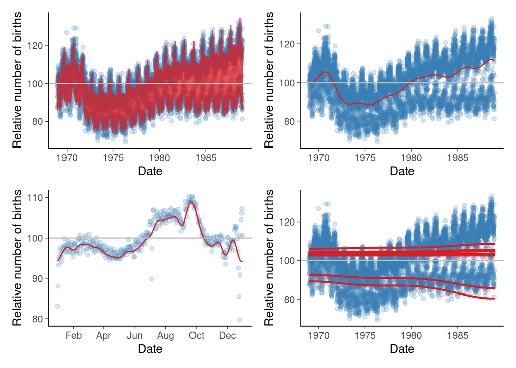

Figure 18

```r
draws4 <- as_draws_matrix(draws4)
Ef <- exp(apply(subset(draws4, variable = "f"), 2, median))
Ef1 <- apply(subset(draws4, variable = "f1"), 2, median)
Ef1 <- exp(Ef1 - mean(Ef1) + mean(log(birthdays$births_relative100)))
Ef2 <- apply(subset(draws4, variable = "f2"), 2, median)
Ef2 <- exp(Ef2 - mean(Ef2) + mean(log(birthdays$births_relative100)))
Ef_day_of_week <- apply(subset(draws4, variable = "f_day_of_week"), 2, median)
Ef_day_of_week <- exp(Ef_day_of_week - mean(Ef_day_of_week) + mean(log(birthdays$births_relative100)))
Ef3 <- apply(subset(draws4, variable = "f3"), 2, median)
Ef3 <- exp(Ef3 - mean(Ef3) + mean(log(birthdays$births_relative100)))
pf   <- make_pf(birthdays, Ef) + layers_hline100
pf1  <- make_pf1(birthdays, Ef1)
pf2  <- make_pf2(birthdays, Ef2, date_breaks = "2 month")
pf3b <- make_pf3b(birthdays, Ef3)
compose_4panel(pf, pf1, pf2, pf3b)
```

The model fits well the different branches visible in plotted daily relative number of births, that is, it is able to model the increasing weekend effect.

Compare the mean and sd of parameters from Pathfinder and MCMC.

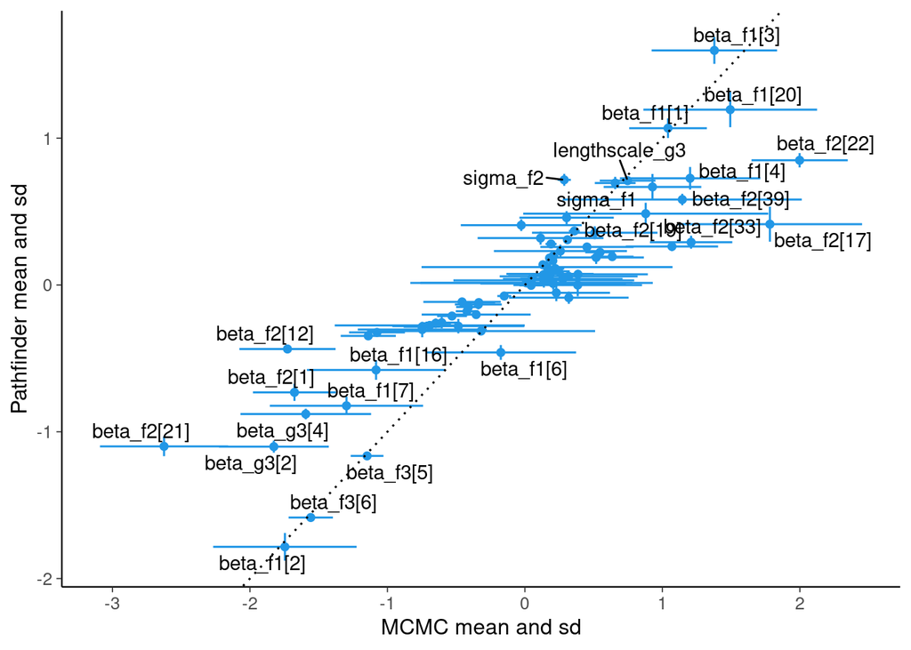

Figure 19

```r
variables <- names(model4$variables()$parameters)
sp <- summarise_draws(subset(pdraws4, variable = variables))
sm <- summarise_draws(subset(draws4, variable = variables))
make_pth_vs_fit(sm, sp)
```

## 5.5 Model 5: long term smooth + seasonal + weekday with time dependent magnitude + day of year RHS

The next component to add is day of year effect. Many bank holidays are every year on the same day of year and there might be also other special days that are favored or disfavored.

$$\begin{aligned}
f & = \mathrm{intercept} + f_1 + f_2 + \exp(g_3)\beta_{\text{day of week}} + \beta_{\text{day of year}}\\
\mathrm{intercept} & \sim \mathrm{normal}(0,1)\\
f_1 & \sim \mathrm{GP}(0,K_1)\\
f_2 & \sim \mathrm{GP}(0,K_2)\\
g_3 & \sim \mathrm{GP}(0,K_3)\\
\beta_{\text{day of week}} & = 0 \quad \text{if day of week is Monday}\\
\beta_{\text{day of week}} & \sim \mathrm{normal}(0,1) \quad \text{if day of week is not Monday}\\
\beta_{\text{day of year}} & \sim \mathrm{RHS}(0,0.1)
\end{aligned}$$
As we assume that only some days of year are special, we use regularized horseshoe (RHS) prior (Piironen and Vehtari 2017) for day of year effects.

At this point the optimization didn’t produce reasonable result as earlier and sampling turned out to be very slow. We assumed the optimization fails because there were so many more parameters with hierarchical prior. As even the short chain sampling would have taken more than hour, it would have been time consuming to further to test the model. As part of the quick iterative model building it was better to give up on this model for a moment. When revisiting this case study and adding Pathfinder approximation, it produced much better results and using it to initialize MCMC, the sampling took only 2.5 minutes.

Compile Stan model 5 gpbf5.stan

```r
model5 <- cmdstan_model(stan_file = root("birthdays", "gpbf5.stan"),
                        include_paths = root("birthdays"))
```

Data to be passed to Stan

```r
standata5 <- list(x = birthdays$id,
                  y = log(birthdays$births_relative100),
                  N = length(birthdays$id),
                  c_f1 = 1.5, # factor c of basis functions for GP for f1
                  M_f1 = 20,  # number of basis functions for GP for f1
                  J_f2 = 20,  # number of basis functions for periodic f2
                  c_g3 = 1.5, # factor c of basis functions for GP for g3
                  M_g3 = 5,   # number of basis functions for GP for g3
                  scale_global = 0.1, # global scale for RHS prior
                  day_of_week = birthdays$day_of_week,
                  day_of_year = birthdays$day_of_year2) # 1st March = 61 every year
```

Pathfinder is faster than sampling (although this result can be useful in a quick workflow, the result should not be used as the final result).

```r
tic('Sampling from Pathfinder approximation of model 5 posterior')
pth5 <- model5$pathfinder(data = standata5, init = 0.1,
                          num_paths = 10, single_path_draws = 40, draws = 400,
                          history_size = 50, max_lbfgs_iters = 100,
                          refresh = 0)
```

```
Pareto k value (10) is greater than 0.7. Importance resampling was not able to improve the approximation, which may indicate that the approximation itself is poor.
Finished in  14.4 seconds.
```

```r
mytoc()
```

Pareto-$\hat{k}$ is even higher, but the Pathfinder draws are likely to be useful for quick analysis and initialization of MCMC sampling.

Check whether parameters have reasonable values

```r
pdraws5 <- pth5$draws()
summarise_draws(subset(pdraws5, variable = c("lp__")), n_distinct) |>
  tt()
```

| variable | n_distinct |
| --- | --- |
| lp__ | 1 |

```r
summarise_draws(subset(pdraws5, variable = c("sigma_", "lengthscale_", "sigma"), regex = TRUE),
                default_summary_measures()) |>
  tt()
```

| variable | mean | median | sd | mad | q5 | q95 |
| --- | --- | --- | --- | --- | --- | --- |
| sigma_f1 | 0.44 | 0.44 | 0 | 0 | 0.44 | 0.44 |
| sigma_f2 | 0.56 | 0.56 | 0 | 0 | 0.56 | 0.56 |
| sigma_g3 | 0.28 | 0.28 | 0 | 0 | 0.28 | 0.28 |
| lengthscale_f1 | 0.2 | 0.2 | 0 | 0 | 0.2 | 0.2 |
| lengthscale_f2 | 0.33 | 0.33 | 0 | 0 | 0.33 | 0.33 |
| lengthscale_g3 | 0.72 | 0.72 | 0 | 0 | 0.72 | 0.72 |
| sigma | 0.26 | 0.26 | 0 | 0 | 0.26 | 0.26 |

```r
summarise_draws(subset(pdraws5, variable = c("beta_f3")),
                default_summary_measures()) |>
  tt()
```

| variable | mean | median | sd | mad | q5 | q95 |
| --- | --- | --- | --- | --- | --- | --- |
| beta_f3[1] | 0.4 | 0.4 | 0 | 0 | 0.4 | 0.4 |
| beta_f3[2] | 0.14 | 0.14 | 0 | 0 | 0.14 | 0.14 |
| beta_f3[3] | 0.053 | 0.053 | 0 | 0 | 0.053 | 0.053 |
| beta_f3[4] | 0.2 | 0.2 | 0 | 0 | 0.2 | 0.2 |
| beta_f3[5] | -1.3 | -1.3 | 0 | 0 | -1.3 | -1.3 |
| beta_f3[6] | -1.7 | -1.7 | 0 | 0 | -1.7 | -1.7 |

We now get only one or couple distinct draws (depending on luck), so we don’t get much information about the posterior width, but the draws are still providing a useful approximation.

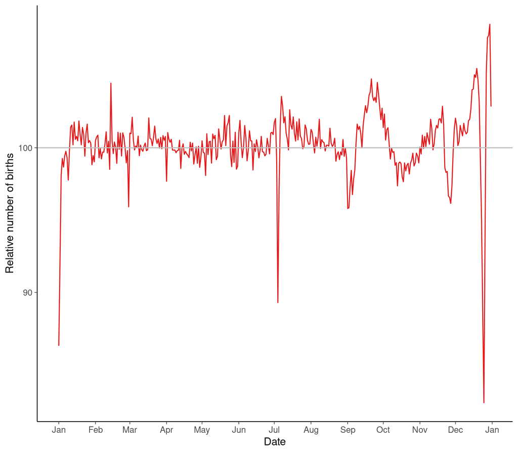

Figure 20

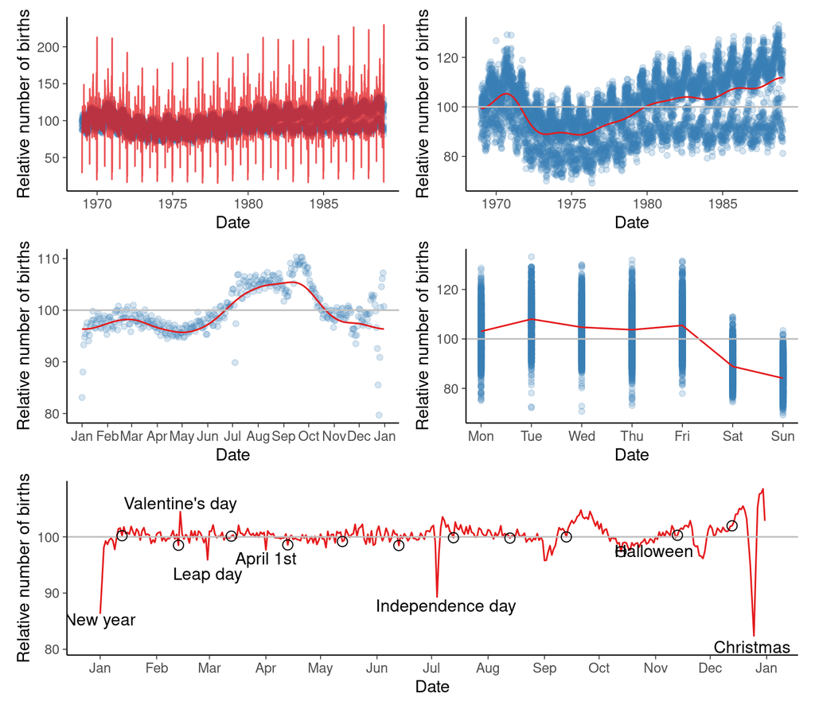

Figure 21

```r
draws5 <- as_draws_matrix(pdraws5)
Ef4 <- apply(subset(draws5, variable = "beta_f4"), 2, median) * sd(log(birthdays$births_relative100))
Ef4 <- exp(Ef4) * 100
data.frame(x = as.Date("1988-01-01") + 0:365, y = Ef4) |>
  ggplot(aes(x = x, y = y)) +
  geom_line(color = col_fit) +
  layers_scale_doy +
  layers_hline100 +
  layers_labs_date
draws5 <- as_draws_matrix(pdraws5)
Ef <- exp(apply(subset(draws5, variable = "f"), 2, median))
Ef1 <- apply(subset(draws5, variable = "f1"), 2, median)
Ef1 <- exp(Ef1 - mean(Ef1) + mean(log(birthdays$births_relative100)))
Ef2 <- apply(subset(draws5, variable = "f2"), 2, median)
Ef2 <- exp(Ef2 - mean(Ef2) + mean(log(birthdays$births_relative100)))
Ef_day_of_week <- apply(subset(draws5, variable = "f_day_of_week"), 2, median)
Ef_day_of_week <- exp(Ef_day_of_week - mean(Ef_day_of_week) + mean(log(birthdays$births_relative100)))
Ef4 <- apply(subset(draws5, variable = "beta_f4"), 2, median) * sd(log(birthdays$births_relative100))
Ef4 <- exp(Ef4) * 100
pf   <- make_pf(birthdays, Ef)
pf1  <- make_pf1(birthdays, Ef1)
pf2  <- make_pf2(birthdays, Ef2)
pf3  <- make_pf3(birthdays, Ef_day_of_week)
f13  <- birthdays |> filter(year == 1988) |> select(day, date) |> mutate(y = Ef4) |> filter(day == 13)
pf2b <- make_pf2b(Ef4, f13, holidays = "fixed")
compose_6panel(pf, pf1, pf2, pf3, pf2b)
```

The quick model fit looks reasonable for a quick fit.

Stan Pathfinder uses Pareto smoothed importance sampling with replacement as default, but when Pareto-$\hat{k}$ is very large that may return less distinct draws than we would like to use for initializing MCMC. In such case we can turn of the PSIS resampling in Stan, and do PSIS without replacement in R.

```r
tic('Sampling from Pathfinder approximation of model 5 posterior')
pth5 <- model5$pathfinder(data = standata5, init = 0.1,
                          num_paths = 10, single_path_draws = 40, draws = 400,
                          history_size = 50, max_lbfgs_iters = 100,
                          refresh = 0, psis_resample = FALSE)
```

```
Finished in  12.8 seconds.
```

```r
mytoc()
```

We check the number of distinct draws, which is now higher (no resampling).

```r
pdraws5 <- pth5$draws()
summarise_draws(subset(pdraws5, variable = c("lp__")), n_distinct) |>
  tt()
```

| variable | n_distinct |
| --- | --- |
| lp__ | 400 |

Do Pareto smoothing of importance weights (with automatic diagnostic).

```r
pdraws5 <- pdraws5 |>
  mutate_variables(lw = lp__ - lp_approx__,
                   w = exp(lw - max(lw)),
                   ws = pareto_smooth(w, tail = "right"))
```

Do importance resampling without replacement. When Pareto-$\hat{k}$ is not too big, for inference we prefer resampling with replacement, but for initializing MCMC we prefer distinct draws, and prefer resampling without replacement.

```r
pdraws5 <- pdraws5 |>
  weight_draws(weights = extract_variable(pdraws5, "ws"), log = FALSE) |>
  resample_draws(ndraws = 4, method = "simple_no_replace")
```

We have now 4 distinct draws.

```r
summarise_draws(subset(pdraws5, variable = c("lp__")), n_distinct) |>
  tt()
```

| variable | n_distinct |
| --- | --- |
| lp__ | 4 |

These steps to obtain 4 distinct draws were for illustration, and sampling initialization makes the same steps internally given a Pathfinder object.

Sample short chains using the Pathfinder result as initial values. (although the result from short chains can be useful in a quick workflow, the result should not be used as the final result).

```r
tic('MCMC sampling from model 5 posterior with Pathfinder initialization')
fit5 <- model5$sample(data = standata5, iter_warmup = 100, iter_sampling = 100,
                      chains = 4, parallel_chains = 4,
                      init = pth5)
```

```r
mytoc()
```

Before using Pathfinder to initialize sampling, the sampling took longer than my patience, and the sampler result was not included in the case study. With Pathfinder initialization, the sampler finished in 2.5 mins, but reported 100% of maximum treedepths which indicates very strong posterior dependencies.

Check whether parameters have reasonable values

```r
draws5 <- fit5$draws()
summarise_draws(subset(draws5, variable = c("sigma_", "lengthscale_", "sigma"), regex = TRUE)) |>
  tt()
```

| variable | mean | median | sd | mad | q5 | q95 | rhat | ess_bulk | ess_tail |
| --- | --- | --- | --- | --- | --- | --- | --- | --- | --- |
| sigma_f1 | 0.69 | 0.67 | 0.14 | 0.13 | 0.49 | 0.95 | 1 | 258 | 230 |
| sigma_f2 | 0.27 | 0.27 | 0.046 | 0.042 | 0.21 | 0.36 | 1 | 240 | 267 |
| sigma_g3 | 0.19 | 0.18 | 0.044 | 0.043 | 0.13 | 0.27 | 1 | 594 | 402 |
| lengthscale_f1 | 0.2 | 0.21 | 0.042 | 0.038 | 0.13 | 0.26 | 1 | 445 | 309 |
| lengthscale_f2 | 0.22 | 0.22 | 0.018 | 0.018 | 0.19 | 0.25 | 1 | 127 | 155 |
| lengthscale_g3 | 0.75 | 0.75 | 0.2 | 0.23 | 0.43 | 1.1 | 1 | 475 | 355 |
| sigma | 0.26 | 0.26 | 0.0021 | 0.0022 | 0.26 | 0.26 | 1 | 386 | 330 |

```r
summarise_draws(subset(draws5, variable = c("beta_f3"))) |>
  tt()
```

| variable | mean | median | sd | mad | q5 | q95 | rhat | ess_bulk | ess_tail |
| --- | --- | --- | --- | --- | --- | --- | --- | --- | --- |
| beta_f3[1] | 0.34 | 0.34 | 0.04 | 0.031 | 0.28 | 0.41 | 1 | 1002 | 305 |
| beta_f3[2] | 0.13 | 0.13 | 0.018 | 0.019 | 0.098 | 0.16 | 1 | 958 | 393 |
| beta_f3[3] | 0.056 | 0.055 | 0.013 | 0.014 | 0.037 | 0.078 | 1 | 552 | 400 |
| beta_f3[4] | 0.18 | 0.18 | 0.023 | 0.022 | 0.14 | 0.22 | 1 | 757 | 416 |
| beta_f3[5] | -1.1 | -1.1 | 0.12 | 0.096 | -1.3 | -0.89 | 1 | 949 | 372 |
| beta_f3[6] | -1.5 | -1.5 | 0.16 | 0.13 | -1.8 | -1.2 | 1 | 1013 | 396 |

Compare the model to the data

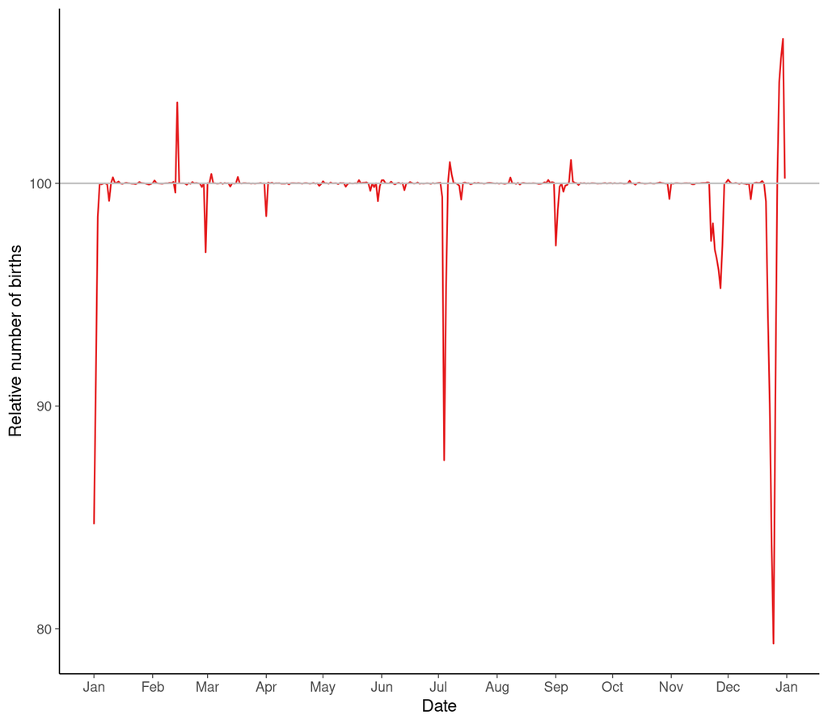

Figure 22

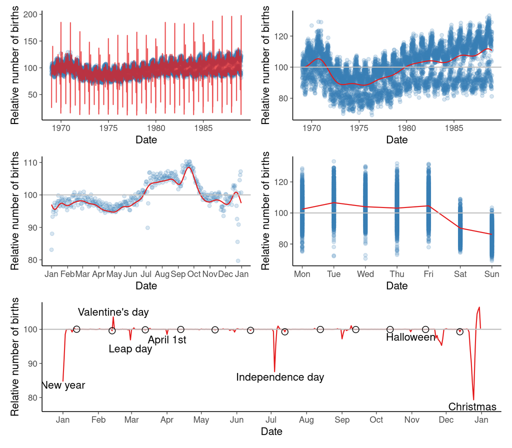

Figure 23

```r
draws5 <- as_draws_matrix(draws5)
Ef4 <- apply(subset(draws5, variable = "beta_f4"), 2, median) * sd(log(birthdays$births_relative100))
Ef4 <- exp(Ef4) * 100
data.frame(x = as.Date("1988-01-01") + 0:365, y = Ef4) |>
  ggplot(aes(x = x, y = y)) +
  geom_line(color = col_fit) +
  layers_scale_doy +
  layers_hline100 +
  layers_labs_date
draws5 <- as_draws_matrix(draws5)
Ef <- exp(apply(subset(draws5, variable = "f"), 2, median))
Ef1 <- apply(subset(draws5, variable = "f1"), 2, median)
Ef1 <- exp(Ef1 - mean(Ef1) + mean(log(birthdays$births_relative100)))
Ef2 <- apply(subset(draws5, variable = "f2"), 2, median)
Ef2 <- exp(Ef2 - mean(Ef2) + mean(log(birthdays$births_relative100)))
Ef_day_of_week <- apply(subset(draws5, variable = "f_day_of_week"), 2, median)
Ef_day_of_week <- exp(Ef_day_of_week - mean(Ef_day_of_week) + mean(log(birthdays$births_relative100)))
Ef4 <- apply(subset(draws5, variable = "beta_f4"), 2, median) * sd(log(birthdays$births_relative100))
Ef4 <- exp(Ef4) * 100
pf   <- make_pf(birthdays, Ef)
pf1  <- make_pf1(birthdays, Ef1)
pf2  <- make_pf2(birthdays, Ef2)
pf3  <- make_pf3(birthdays, Ef_day_of_week)
f13  <- birthdays |> filter(year == 1988) |> select(day, date) |> mutate(y = Ef4) |> filter(day == 13)
pf2b <- make_pf2b(Ef4, f13, holidays = "fixed")
compose_6panel(pf, pf1, pf2, pf3, pf2b)
```

The plot looks quite good. Compare the mean and sd of parameters from Pathfinder and MCMC. In this case, we are using the non-resampled Pathfinder draws (the resampled draws had only one distinct draw). Compare the mean and sd of parameters from Pathfinder and MCMC. We see that MCMC estimates of sd for some parameters are super high, indicating a bad model. Instead of trying to get the computation to work better, we drop this model at the moment.

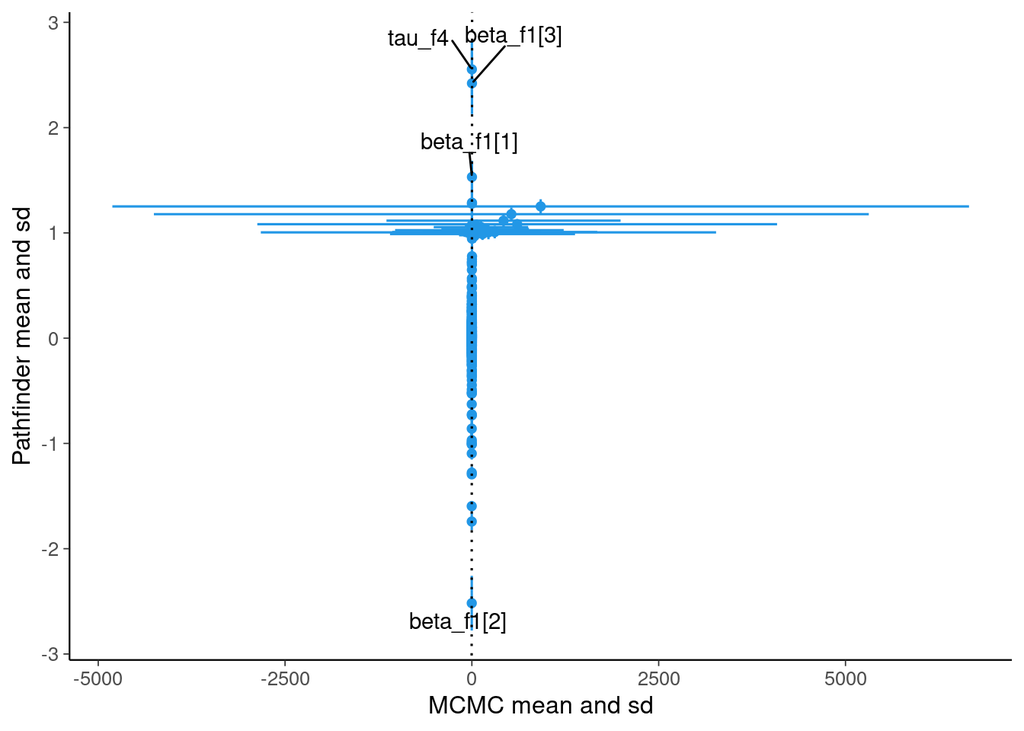

Figure 24

```r
variables <- names(model5$variables()$parameters)
sp <- summarise_draws(subset(pth5$draws(), variable = variables))
sm <- summarise_draws(subset(draws5, variable = variables))
make_pth_vs_fit(sm, sp)
```

## 5.6 Model 6: long term smooth + seasonal + weekday + day of year

To simplify the analysis of the day of year effect and make the inference during the exploration faster, we drop the time dependent day of week effect and RHS for a moment and use normal prior for the day of year effect.

$$\begin{aligned}
f & = \mathrm{intercept} + f_1 + f_2 + \beta_{\text{day of week}} + \beta_{\text{day of year}}\\
\mathrm{intercept} & \sim \mathrm{normal}(0,1)\\
f_1 & \sim \mathrm{GP}(0,K_1)\\
f_2 & \sim \mathrm{GP}(0,K_2)\\
\beta_{\text{day of week}} & = 0 \quad \text{if day of week is Monday}\\
\beta_{\text{day of week}} & \sim \mathrm{normal}(0,1) \quad \text{if day of week is not Monday}\\
\beta_{\text{day of year}} & \sim \mathrm{normal}(0,0.1)
\end{aligned}$$

Compile Stan model 6 gpbf6.stan

```r
model6 <- cmdstan_model(stan_file = root("birthdays", "gpbf6.stan"),
                        include_paths = root("birthdays"))
```

Data to be passed to Stan

```r
standata6 <- list(x = birthdays$id,
                  y = log(birthdays$births_relative100),
                  N = length(birthdays$id),
                  c_f1 = 1.5, # factor c of basis functions for GP for f1
                  M_f1 = 20, # number of basis functions for GP for f1
                  J_f2 = 20, # number of basis functions for periodic f2
                  day_of_week = birthdays$day_of_week,
                  day_of_year = birthdays$day_of_year2) # 1st March = 61 every year
```

Pathfinder is faster than sampling (although this result can be useful in a quick workflow, the result should not be used as the final result).

```r
tic('Sampling from Pathfinder approximation of model 6 posterior')
pth6 <- model6$pathfinder(data = standata6, init = 0.1,
                          num_paths = 10, single_path_draws = 40, draws = 400,
                          history_size = 50, max_lbfgs_iters = 100,
                          refresh = 0)
```

```
Pareto k value (9.4) is greater than 0.7. Importance resampling was not able to improve the approximation, which may indicate that the approximation itself is poor.
Finished in  7.5 seconds.
```

```r
mytoc()
```

Pathfinder provides automatically Pareto-$\hat{k}$ diagnostic which is high, indicating the normal approximation is not good. When Pareto-$\hat{k}$ is very high the Pareto smoothed importance sampling returns less distinct draws, and it is useful to check that, too.

```r
pdraws6 <- pth6$draws()
summarise_draws(subset(pdraws6, variable = c("lp__")), n_distinct) |>
  tt()
```

| variable | n_distinct |
| --- | --- |
| lp__ | 1 |

```r
summarise_draws(subset(pdraws6, variable = c("sigma_", "lengthscale_", "sigma"), regex = TRUE),
                default_summary_measures()) |>
  tt()
```

| variable | mean | median | sd | mad | q5 | q95 |
| --- | --- | --- | --- | --- | --- | --- |
| sigma_f1 | 0.55 | 0.55 | 0 | 0 | 0.55 | 0.55 |
| sigma_f2 | 0.94 | 0.94 | 0 | 0 | 0.94 | 0.94 |
| sigma_f4 | 0.16 | 0.16 | 0 | 0 | 0.16 | 0.16 |
| lengthscale_f1 | 0.19 | 0.19 | 0 | 0 | 0.19 | 0.19 |
| lengthscale_f2 | 0.2 | 0.2 | 0 | 0 | 0.2 | 0.2 |
| sigma | 0.28 | 0.28 | 0 | 0 | 0.28 | 0.28 |

```r
summarise_draws(subset(pdraws6, variable = c("beta_f3")),
                default_summary_measures()) |>
  tt()
```

| variable | mean | median | sd | mad | q5 | q95 |
| --- | --- | --- | --- | --- | --- | --- |
| beta_f3[1] | 0.36 | 0.36 | 0 | 0 | 0.36 | 0.36 |
| beta_f3[2] | 0.15 | 0.15 | 0 | 0 | 0.15 | 0.15 |
| beta_f3[3] | 0.054 | 0.054 | 0 | 0 | 0.054 | 0.054 |
| beta_f3[4] | 0.19 | 0.19 | 0 | 0 | 0.19 | 0.19 |
| beta_f3[5] | -1.1 | -1.1 | 0 | 0 | -1.1 | -1.1 |
| beta_f3[6] | -1.5 | -1.5 | 0 | 0 | -1.5 | -1.5 |

Again we get only one or couple distinct draws (depending on luck), so we don’t get much information about the posterior width, but the draws are still providing a useful approximation.

Compare the model to the data

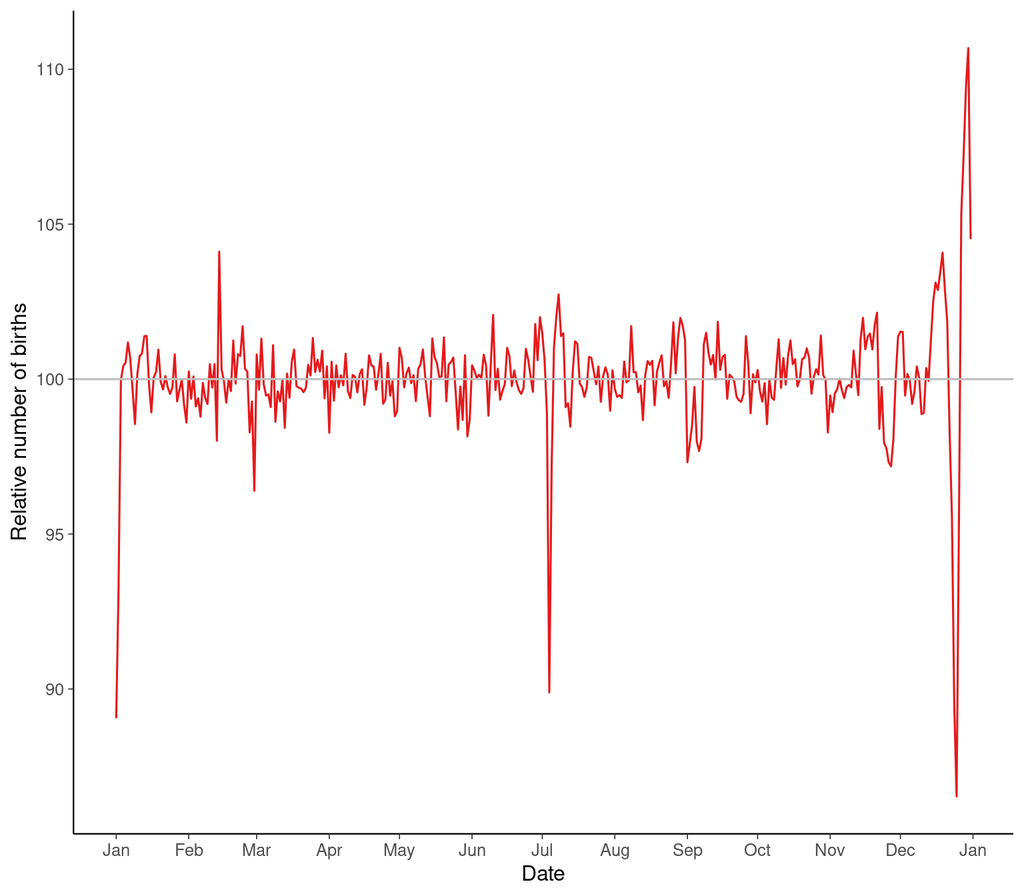

Figure 25

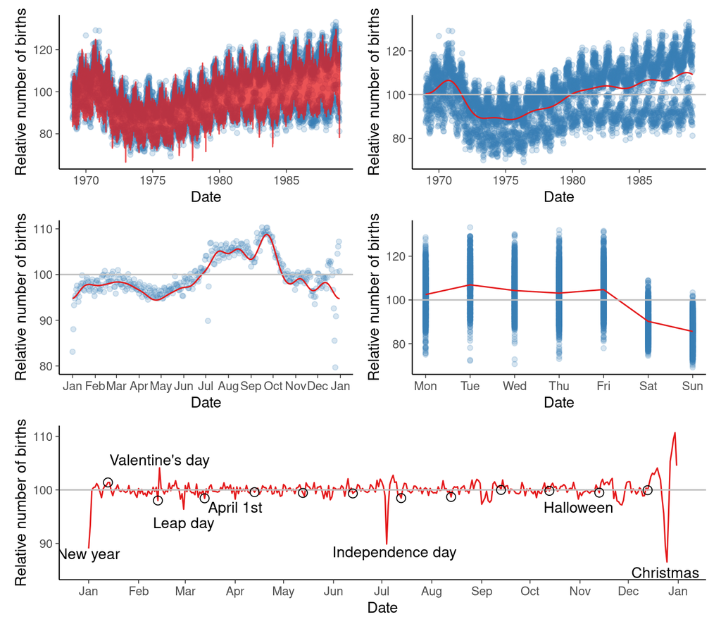

Figure 26

```r
draws6 <- as_draws_matrix(pdraws6)
Ef4 <- apply(subset(draws6, variable = "beta_f4"), 2, median) * sd(log(birthdays$births_relative100))
Ef4 <- exp(Ef4) * 100
data.frame(x = as.Date("1988-01-01") + 0:365, y = Ef4) |>
  ggplot(aes(x = x, y = y)) +
  geom_line(color = col_fit) +
  layers_scale_doy +
  layers_hline100 +
  layers_labs_date
draws6 <- as_draws_matrix(draws6)
Ef <- exp(apply(subset(draws6, variable = "f"), 2, median))
Ef1 <- apply(subset(draws6, variable = "f1"), 2, median)
Ef1 <- exp(Ef1 - mean(Ef1) + mean(log(birthdays$births_relative100)))
Ef2 <- apply(subset(draws6, variable = "f2"), 2, median)
Ef2 <- exp(Ef2 - mean(Ef2) + mean(log(birthdays$births_relative100)))
Ef_day_of_week <- apply(subset(draws6, variable = "f_day_of_week"), 2, median)
Ef_day_of_week <- exp(Ef_day_of_week - mean(Ef_day_of_week) + mean(log(birthdays$births_relative100)))
Ef4 <- apply(subset(draws6, variable = "beta_f4"), 2, median) * sd(log(birthdays$births_relative100))
Ef4 <- exp(Ef4) * 100
pf   <- make_pf(birthdays, Ef)
pf1  <- make_pf1(birthdays, Ef1)
pf2  <- make_pf2(birthdays, Ef2)
pf3  <- make_pf3(birthdays, Ef_day_of_week)
f13  <- birthdays |> filter(year == 1988) |> select(day, date) |> mutate(y = Ef4) |> filter(day == 13)
pf2b <- make_pf2b(Ef4, f13, holidays = "fixed")
compose_6panel(pf, pf1, pf2, pf3, pf2b)
```

We recognize some familiar structure in the day of year effect and proceed to sampling.

```r
tic('Sampling from Pathfinder approximation of model 6 posterior')
pth6 <- model6$pathfinder(data = standata6, init = 0.1,
                          num_paths = 10, single_path_draws = 40, draws = 400,
                          history_size = 50, max_lbfgs_iters = 100,
                          refresh = 0, psis_resample = FALSE)
```

```
Finished in  8.0 seconds.
```

```r
mytoc()
```

[output not shown]

Sample short chains using the Pathfinder result as initial values (although the result from short chains can be useful in a quick workflow, the result should not be used as the final result).

```r
tic('MCMC sampling from model 6 posterior with Pathfinder initialization')
fit6 <- model6$sample(data = standata6, iter_warmup = 100, iter_sampling = 100,
                      chains = 4, parallel_chains = 4,
                      init = pth6)
```

```r
mytoc()
```

Check whether parameters have reasonable values

```r
draws6 <- fit6$draws()
summarise_draws(subset(draws6, variable = c("sigma_", "lengthscale_", "sigma"), regex = TRUE)) |>
  tt()
```

| variable | mean | median | sd | mad | q5 | q95 | rhat | ess_bulk | ess_tail |
| --- | --- | --- | --- | --- | --- | --- | --- | --- | --- |
| sigma_f1 | 0.65 | 0.64 | 0.12 | 0.12 | 0.47 | 0.87 | 1.1 | 48 | 107 |
| sigma_f2 | 0.29 | 0.29 | 0.055 | 0.059 | 0.21 | 0.39 | 1.1 | 31 | 45 |
| sigma_f4 | 0.17 | 0.17 | 0.0078 | 0.008 | 0.16 | 0.19 | 1 | 444 | 308 |
| lengthscale_f1 | 0.21 | 0.21 | 0.036 | 0.034 | 0.14 | 0.26 | 1.1 | 34 | 72 |
| lengthscale_f2 | 0.25 | 0.25 | 0.028 | 0.027 | 0.21 | 0.3 | 1.1 | 31 | 67 |
| sigma | 0.29 | 0.29 | 0.0024 | 0.0027 | 0.28 | 0.29 | 1 | 422 | 342 |

```r
summarise_draws(subset(draws6, variable = c("beta_f3"))) |>
  tt()
```

| variable | mean | median | sd | mad | q5 | q95 | rhat | ess_bulk | ess_tail |
| --- | --- | --- | --- | --- | --- | --- | --- | --- | --- |
| beta_f3[1] | 0.35 | 0.35 | 0.013 | 0.014 | 0.33 | 0.38 | 1 | 488 | 311 |
| beta_f3[2] | 0.13 | 0.13 | 0.013 | 0.013 | 0.11 | 0.15 | 1 | 394 | 335 |
| beta_f3[3] | 0.046 | 0.046 | 0.012 | 0.012 | 0.025 | 0.065 | 1 | 455 | 334 |
| beta_f3[4] | 0.18 | 0.18 | 0.013 | 0.015 | 0.16 | 0.2 | 1 | 513 | 331 |
| beta_f3[5] | -1.1 | -1.1 | 0.014 | 0.014 | -1.1 | -1.1 | 1 | 416 | 335 |
| beta_f3[6] | -1.5 | -1.5 | 0.013 | 0.014 | -1.5 | -1.5 | 1 | 481 | 393 |

Compare the model to the data

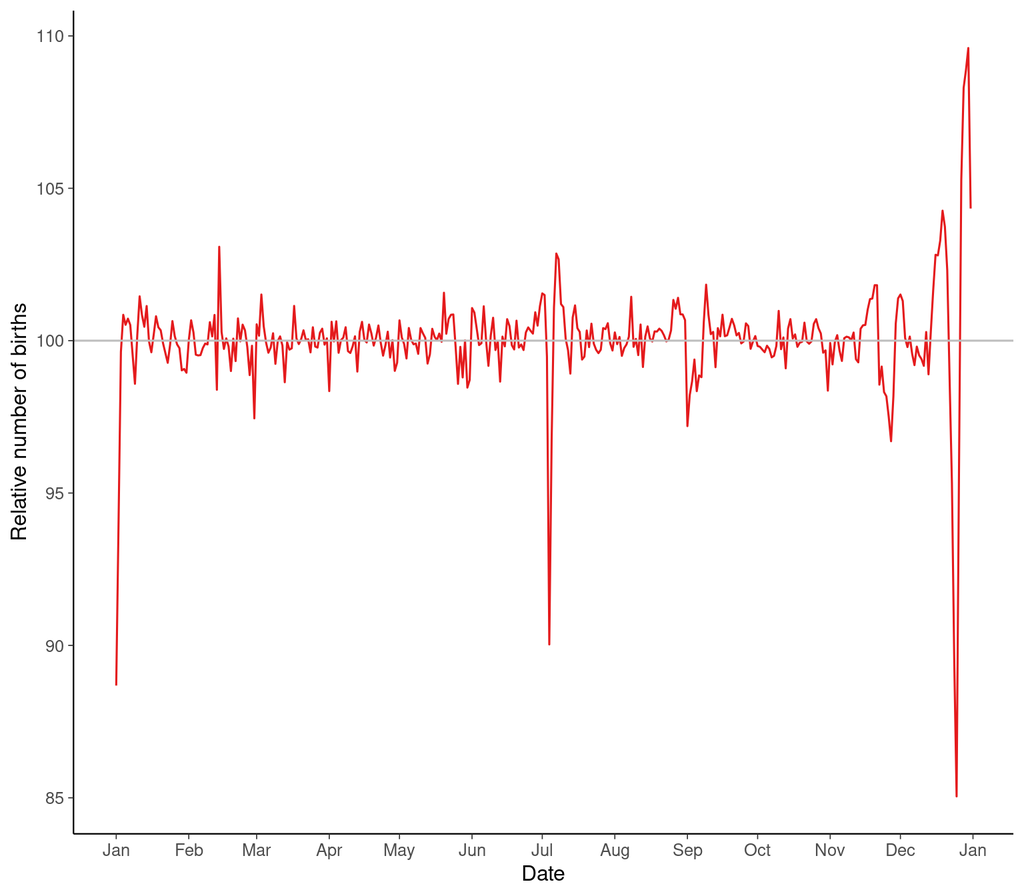

Figure 27

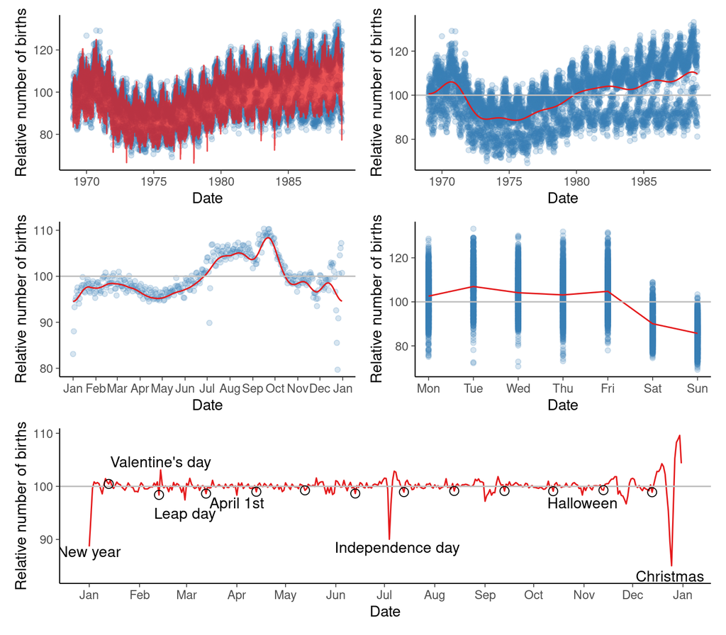

Figure 28

```r
draws6 <- as_draws_matrix(draws6)
Ef4 <- apply(subset(draws6, variable = "beta_f4"), 2, median) * sd(log(birthdays$births_relative100))
Ef4 <- exp(Ef4) * 100
data.frame(x = as.Date("1988-01-01") + 0:365, y = Ef4) |>
  ggplot(aes(x = x, y = y)) +
  geom_line(color = col_fit) +
  layers_scale_doy +
  layers_hline100 +
  layers_labs_date
draws6 <- as_draws_matrix(draws6)
Ef <- exp(apply(subset(draws6, variable = "f"), 2, median))
Ef1 <- apply(subset(draws6, variable = "f1"), 2, median)
Ef1 <- exp(Ef1 - mean(Ef1) + mean(log(birthdays$births_relative100)))
Ef2 <- apply(subset(draws6, variable = "f2"), 2, median)
Ef2 <- exp(Ef2 - mean(Ef2) + mean(log(birthdays$births_relative100)))
Ef_day_of_week <- apply(subset(draws6, variable = "f_day_of_week"), 2, median)
Ef_day_of_week <- exp(Ef_day_of_week - mean(Ef_day_of_week) + mean(log(birthdays$births_relative100)))
Ef4 <- apply(subset(draws6, variable = "beta_f4"), 2, median) * sd(log(birthdays$births_relative100))
Ef4 <- exp(Ef4) * 100
pf   <- make_pf(birthdays, Ef)
pf1  <- make_pf1(birthdays, Ef1)
pf2  <- make_pf2(birthdays, Ef2)
pf3  <- make_pf3(birthdays, Ef_day_of_week)
f13  <- birthdays |> filter(year == 1988) |> select(day, date) |> mutate(y = Ef4) |> filter(day == 13)
pf2b <- make_pf2b(Ef4, f13, holidays = "fixed")
compose_6panel(pf, pf1, pf2, pf3, pf2b)
```

The short sampling result looks reasonable and thus the problem is not in adding the day of year effect itself. In the bottom plot, the circles mark 13th day of each month. Results look similar to our previous analyses (Gelman et al. 2013), so it seems the day or year effect model component is working as it should, but there was some problem with our RHS implementation. As there is more variation in the day of year effects than we would hope, we did some additional experiments with different priors for the day of year effect (double exponential, Cauchy and Student’s t with unknown degrees of freedom as models 6b, 6c, 6d), but decided it’s better to add other components before investing that part more thoroughly.

Compare the mean and sd of parameters from Pathfinder and MCMC. In this case, we are using the non-resampled Pathfinder draws.

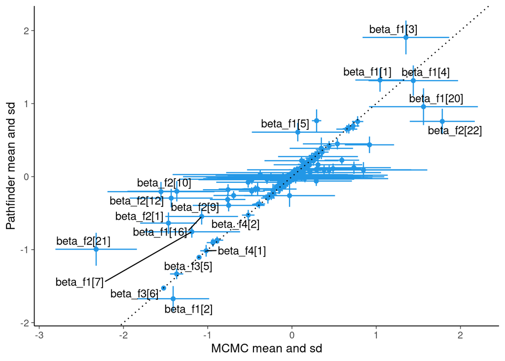

Figure 29

```r
variables <- names(model6$variables()$parameters)
sp <- summarise_draws(subset(pth6$draws(), variable = variables))
sm <- summarise_draws(subset(draws6, variable = variables))
make_pth_vs_fit(sm, sp)
```

The following plot shows the day of year effect with 90% posterior intervals.

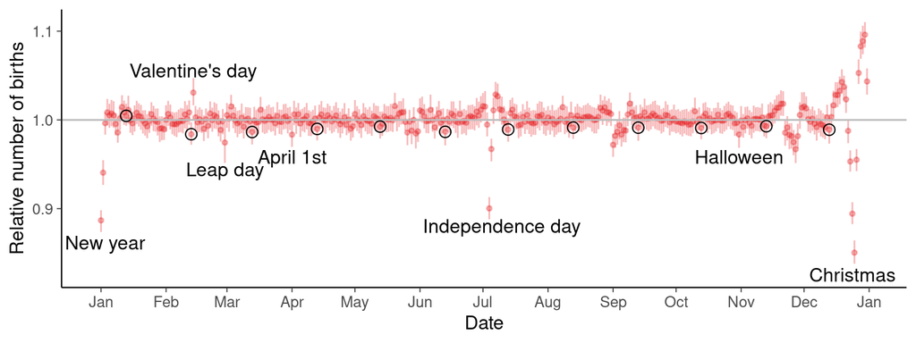

Figure 30

```r
draws6r <- as_draws_rvars(draws6)
Ef4r <- exp(draws6r$beta_f4*sd(log(birthdays$births_relative100)))
draws6 <- as_draws_matrix(draws6)
Ef4 <- apply(subset(draws6, variable = "beta_f4"), 2, median) * sd(log(birthdays$births_relative100))
Ef4 <- exp(Ef4)
f13  <- birthdays |> filter(year == 1988) |> select(day, date) |> mutate(y = Ef4) |> filter(day == 13)
pf2c <- make_pf2c(Ef4, Ef4r, f13, holidays = "fixed")
pf2c
```

In this plot, it seems like almost all 13th days have fewer births. If we look at the mean effect over all 13th days, the probability that the relative number of births is less than 1 is 100%, although with a small estimated effect of 0.9% fewer births.

## 5.7 Model 7: long term smooth + seasonal + weekday + day of year normal + floating special days

We can see in the model 6 results that day of year effects have some dips in the relative number of births that are spread over a week. From previous analyse we know these correspond to holidays that are not on a specific day of year, but are for example on the last Monday of May. We call these floating special days and include Memorial day (last Monday of May), Labor day (first Monday of September, and we include also the following Tuesday), and Thanksgiving (fourth Thursday of November, and we include also the following Friday).

Compile Stan model 7 gpbf7.stan

```r
model7 <- cmdstan_model(stan_file = root("birthdays", "gpbf7.stan"),
                        include_paths = root("birthdays"))
```

Floating special days

```r
# Memorial day
memorial_days <- with(birthdays, which(month == 5 & day_of_week == 1 & day >= 25))
# Labor day
labor_days <- with(birthdays, which(month == 9 & day_of_week == 1 & day <= 7))
labor_days <- c(labor_days, labor_days + 1)
# Thanksgiving
thanksgiving_days <- with(birthdays, which(month == 11 & day_of_week == 4 & day >= 22 & day <= 28))
thanksgiving_days <- c(thanksgiving_days, thanksgiving_days + 1)
```

Data to be passed to Stan

```r
standata7 <- list(x = birthdays$id,
                  y = log(birthdays$births_relative100),
                  N = length(birthdays$id),
                  c_f1 = 1.5, # factor c of basis functions for GP for f1
                  M_f1 = 20,  # number of basis functions for GP for f1
                  J_f2 = 20,  # number of basis functions for periodic f2
                  day_of_week = birthdays$day_of_week,
                  day_of_year = birthdays$day_of_year2, # 1st March = 61 every year
                  memorial_days = memorial_days,
                  labor_days = labor_days,
                  thanksgiving_days = thanksgiving_days)
```

Pathfinder is faster than sampling (although this result can be useful in a quick workflow, the result should not be used as the final result).

```r
tic('Sampling from Pathfinder approximation of model 7 posterior')
pth7 <- model7$pathfinder(data = standata7, init = 0.1,
                          num_paths = 10, single_path_draws = 40, draws = 400,
                          history_size = 50, max_lbfgs_iters = 100,
                          refresh = 0)
```

```
Pareto k value (9.6) is greater than 0.7. Importance resampling was not able to improve the approximation, which may indicate that the approximation itself is poor.
Finished in  7.6 seconds.
```

```r
mytoc()
```

Check whether parameters have reasonable values

```r
pdraws7 <- pth7$draws()
summarise_draws(subset(pdraws7, variable = c("lp__")), n_distinct) |>
  tt()
```

| variable | n_distinct |
| --- | --- |
| lp__ | 1 |

```r
summarise_draws(subset(pdraws7, variable = c("sigma_", "lengthscale_", "sigma"), regex = TRUE),
                default_summary_measures()) |>
  tt()
```

| variable | mean | median | sd | mad | q5 | q95 |
| --- | --- | --- | --- | --- | --- | --- |
| sigma_f1 | 0.6 | 0.6 | 0 | 0 | 0.6 | 0.6 |
| sigma_f2 | 0.78 | 0.78 | 0 | 0 | 0.78 | 0.78 |
| sigma_f4 | 0.16 | 0.16 | 0 | 0 | 0.16 | 0.16 |
| lengthscale_f1 | 0.2 | 0.2 | 0 | 0 | 0.2 | 0.2 |
| lengthscale_f2 | 0.18 | 0.18 | 0 | 0 | 0.18 | 0.18 |
| sigma | 0.26 | 0.26 | 0 | 0 | 0.26 | 0.26 |

```r
summarise_draws(subset(pdraws7, variable = c("beta_f3")),
                default_summary_measures()) |>
  tt()
```

| variable | mean | median | sd | mad | q5 | q95 |
| --- | --- | --- | --- | --- | --- | --- |
| beta_f3[1] | 0.29 | 0.29 | 0 | 0 | 0.29 | 0.29 |
| beta_f3[2] | 0.074 | 0.074 | 0 | 0 | 0.074 | 0.074 |
| beta_f3[3] | 0.039 | 0.039 | 0 | 0 | 0.039 | 0.039 |
| beta_f3[4] | 0.14 | 0.14 | 0 | 0 | 0.14 | 0.14 |
| beta_f3[5] | -1.2 | -1.2 | 0 | 0 | -1.2 | -1.2 |
| beta_f3[6] | -1.6 | -1.6 | 0 | 0 | -1.6 | -1.6 |

Again we get only one or couple distinct draws (depending on luck).

Compare the model to the data

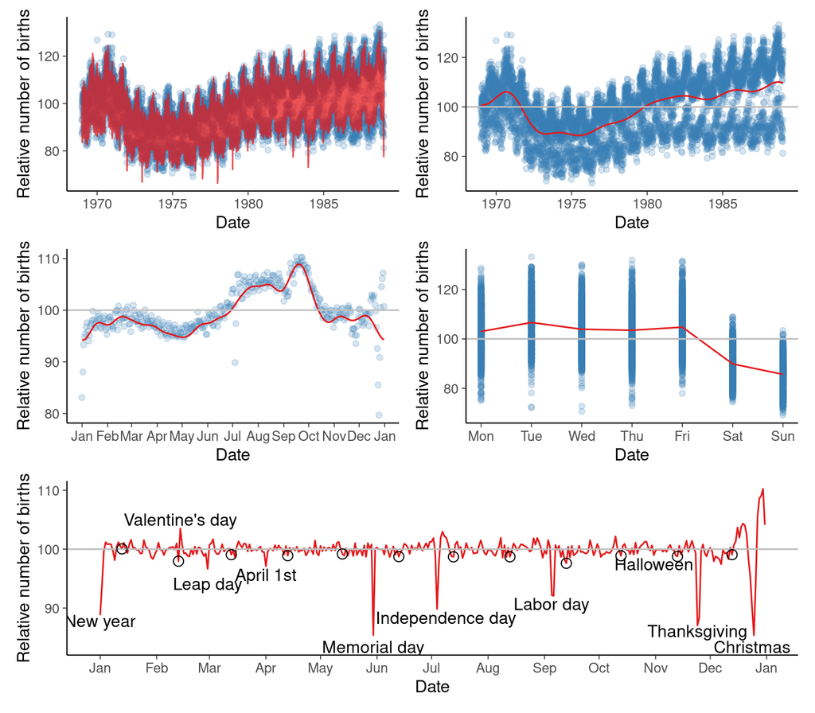

Figure 31

```r
draws7 <- as_draws_matrix(pdraws7)
Ef <- exp(apply(subset(draws7, variable = "f"), 2, median))
Ef1 <- apply(subset(draws7, variable = "f1"), 2, median)
Ef1 <- exp(Ef1 - mean(Ef1) + mean(log(birthdays$births_relative100)))
Ef2 <- apply(subset(draws7, variable = "f2"), 2, median)
Ef2 <- exp(Ef2 - mean(Ef2) + mean(log(birthdays$births_relative100)))
Ef_day_of_week <- apply(subset(draws7, variable = "f_day_of_week"), 2, median)
Ef_day_of_week <- exp(Ef_day_of_week - mean(Ef_day_of_week) + mean(log(birthdays$births_relative100)))
Ef4 <- apply(subset(draws7, variable = "beta_f4"), 2, median) * sd(log(birthdays$births_relative100))
Ef4 <- exp(Ef4) * 100
Efloats <- apply(subset(draws7, variable = "beta_f5"), 2, median) * sd(log(birthdays$births_relative100))
Efloats <- exp(Efloats) * 100
floats1988 <- c(memorial_days[20], labor_days[c(20, 40)], thanksgiving_days[c(20, 40)]) - 6939
Ef4float <- Ef4
Ef4float[floats1988] <- Ef4float[floats1988] * Efloats[c(1, 2, 2, 3, 3)] / 100
pf   <- make_pf(birthdays, Ef)
pf1  <- make_pf1(birthdays, Ef1)
pf2  <- make_pf2(birthdays, Ef2)
pf3  <- make_pf3(birthdays, Ef_day_of_week)
f13  <- birthdays |> filter(year == 1988) |> select(day, date) |> mutate(y = Ef4float) |> filter(day == 13)
pf2b <- make_pf2b(Ef4float, f13, holidays = "floating")
compose_6panel(pf, pf1, pf2, pf3, pf2b)
```

Turn of the PSIS resampling in Stan to get distinct draws for initialization.

```r
tic('Sampling from Pathfinder approximation of model 7 posterior')
pth7 <- model7$pathfinder(data = standata7, init = 0.1,
                          num_paths = 10, single_path_draws = 40, draws = 400,
                          history_size = 50, max_lbfgs_iters = 100,
                          refresh = 0, psis_resample = FALSE)
```

```
Finished in  7.9 seconds.
```

```r
mytoc()
```

[output not shown]

Sample short chains using the Pathfinder result as initial values (although the result from short chains can be useful in a quick workflow, the result should not be used as the final result).

```r
tic('MCMC sampling from model 7 posterior with Pathfinder initialization')
fit7 <- model7$sample(data = standata7, iter_warmup = 100, iter_sampling = 100,
                      chains = 4, parallel_chains = 4,
                      init = pth7)
```

```r
mytoc()
```

Check whether parameters have reasonable values

```r
draws7 <- fit7$draws()
summarise_draws(subset(draws7, variable = c("sigma_", "lengthscale_", "sigma"), regex = TRUE)) |>
  tt()
```

| variable | mean | median | sd | mad | q5 | q95 | rhat | ess_bulk | ess_tail |
| --- | --- | --- | --- | --- | --- | --- | --- | --- | --- |
| sigma_f1 | 0.68 | 0.64 | 0.24 | 0.23 | 0.39 | 1.1 | 2.4 | 5.3 | 15 |
| sigma_f2 | 0.29 | 0.28 | 0.047 | 0.04 | 0.23 | 0.38 | 1.6 | 7.1 | 18 |
| sigma_f4 | 0.17 | 0.17 | 0.0071 | 0.0075 | 0.16 | 0.18 | 1 | 492 | 255 |
| lengthscale_f1 | 0.22 | 0.22 | 0.026 | 0.024 | 0.18 | 0.27 | 1.7 | 6.9 | 16 |
| lengthscale_f2 | 0.3 | 0.3 | 0.026 | 0.026 | 0.25 | 0.34 | 1.2 | 18 | 110 |
| sigma | 0.26 | 0.26 | 0.0023 | 0.0023 | 0.26 | 0.27 | 1 | 432 | 295 |